# Tom’s Statistics and Data Science Toolkit (tsdst)

#### 2.4.1.10 showChain

This method may be redundant. It prints the chain to the console using the python print method. It has the same effect as calling `mcmcObject.chains['chainName']`, except that the chain can’t be stored from the `showChain` method.

Display a chain from the collection.

```
Parameters
----------
chainName : str
    The name of the chain from the collection to display.

Returns
-------
None.
```

```python
showChain(chainName)
```

#### 2.4.1.11 TJ_Convergence_test

This is a homemade convergence test for MCMC chains developed by Tom Werner and Joel Linford (TJ). While these ideas were novel to them at the time of discovery, it has since been revealed that their methods are related or similar to diagnostics proposed by more noteworthy statisticians, such as Heidelberger and Welch or Gewke. Still, this method has proven to perform well when compared with more well-known methods.

This method uses moving windows (default is 5) to “slide” across the chain (starting from the beginning) and measure the given quantiles of the chain in each window (for example, the top 5% or the lower 5%), and compare that with the equivalent quantile values at the end of the chain. If all 5 windows are within some percent difference (`eps`, percent expressed in decimals) of the ending quantiles, then the chain is assumed to have reached a stationary distribution. `bin_limit` is defined as the percentage of the chain (starting from the beginning) that the windows are allowed to pass through. If any of the windows pass by the `bin_limt`, then the chain is said to have not reached stationarity.

If `window_size=None`, then the window size is determined to be 5% of the total numbers of rows. `slide` is how much the windows move down the chain after each iteration, and `window_space` is the amount of space between windows. `eps` is the tolerance of the percent difference. `quantiles` should be a list of decimals representing the quantiles of interest.

This method requires some assumptions:

1. That the chain has been run long enough to have already reached stationarity of the target distribution, not stationarity of an arbitrary distribution
   - For example, this could be used after the Raftery diagnostic or after obtaining a sufficient number of Effective samples
2. That the burn-in value is being interpreted as the closest points in the chain to which stationarity occurs, and that the maximum value between parameters is chosen for the burn-in value
3. That both parameters must pass for the burn-in value to be valid and for the chain to be considered reaching stationarity.

```python
TJ_Convergence_test(self, chainName, eps=0.025, quantiles=[0.05, 0.95],
                    window_size=None, num_windows=5, slide=50,
                    window_space=0, bin_limit=0.6, print_final=False)
```

### 2.4.2 Other Supporting Functions

The following methods are not part of the mcmcObject class. Instead, they are supporting functions that are imported as part of `import tsdst.mcmc`.

#### 2.4.2.1 applyMCMC

Due to some randomness that causes errors when computing the square root of a matrix (using Cholesky decomposition in most cases), this method will run the MCMC algorithms until the computation succeeds. The default is to try 100 times, and jitter the starting values with random decimals every 5 iterations. For example, at every 5th iteration, `st` is jittered by $RV$ where $RV \sim N(0, sd)$, therefore $st := st + RV$.

```
Parameters
----------
st : numpy array
    An array of the parameter starting values.
ni : int
    NUmber of MCMC iterations.
lp : function
    Function for the log posterior.
algo : function
    MCMC algorithm to be performed.
algoOpts : dict, optional
    Specific options for the MCMC algorithm. The default is None.
postArgs : dict, optional
    Specific options for the posterior function. The default is None.
sd : float, optional
    The standard deviation of the normal distribution used to draw the
    jitter amount from. In other words, the jittered covariance is the
    covaraince matrix plus a random draw X, where X~N(0, sd).
    The default is 0.02.
max_tries : int, optional
    The max number of times to try and jitter before admitting defeat.
    If the jitter fails, the reason or the covaraince matrix not being
    positive definite may not be due to randomness, and may require
    a re-evaluation of the problem space. The default is 100.

Raises
------
ValueError
    Raised when cholesky decomposition fails after max_tries.

Returns
-------
res : tuple
    Returns tuple containing the MCMC results.
```

```python
applyMCMC(st, ni, lp, algo, algoOpts=None, postArgs={},
          sd=0.02, max_tries=100)
```

#### 2.4.2.2 cholupdate

Performs a rank 1 update of a Cholesky decomposition. If `update=False`, then it performs a downdate. It’s mainly used in adaptive_mcmc to help generate the covariance matrix (see adaptive_mcmc for details). An update will add x to L while a downdate will subtract x from L.

```
Parameters
----------
L : numpy array (float)
    The upper-triangular decomposed matrix, shape=(N, N).
x : numpy array (float)
    The values being added to L, shape=(N, ).
update : bool, optional
    Perform an update (as opposed to a downdate). The default is True.

Returns
-------
L : numpy array
    Return updated L matrix.
```

```python
cholupdate(L, x, update=True)
```

#### 2.4.2.3 minESS

Translated from the R mcmcse package.

Calculates the minimum Effective Sample Size, independent of the MCMC chain for the given number of parameters. `alpha` is the confidence level, `eps` is the tolerance level (ignored when `ess is not None`), and `ess` is the effective sample size. When `ess is not None`, the function returns the tolerance level needed to obtain that ESS.

In practice, the user should find the minESS amount and then sample until they hit that number. Usually, it is computationally difficult to obtain the optimal minimum effective sample size, therefore, it is useful to know what tolerance is needed to obtain the samples that can be afforded computationally.

see mulitESS or [mcmcse::minESS](https://cran.r-project.org/web/packages/mcmcse/mcmcse.pdf) for more information.

```
Parameters
----------
p : int
    The dimension of the estimation problem (i.e. the number of parameters
    represented in the MCMC chain, or the number of columns in the MCMC
    chain).
alpha : float, optional
    Confidence level. The default is 0.05.
eps : float, optional
    Tolerance level. The smaller the tolerance, the larger the minimum
    effective samples. The default is 0.05.
ess : int, optional
    Estimated effective sample size. The default is None.

Returns
-------
int
    The minimum effective sample required for a given eps tolerance.
    If ess is specified, then the value returned is the eps corresponding
    to that ess.
```

```python
minESS(p, alpha=0.05, eps=0.05, ess=None)
```

#### 2.4.2.4 mulitESS

This function computes the Effective Sample Size of an MCMC chain. Due to correlation between MCMC samples, it is sometimes unclear how much information about the parameters has been obtained. If all of the MCMC samples were independent, we would need less samples to get accurate information about the posterior than when the samples are correlated. ESS measures the amount of independent samples that have actually been obtained in the MCMC chain, and mESS is a special case for multivariate posteriors. In other words, this method is a way to test if your chain has gone far enough.

This information can used in conjunction with minESS, such that the chain has sampled enough when $multiESS >= minESS$.

This code is a translation of the R package `mcmcse`. For more information regarding these functions, see their [documentation](https://cran.r-project.org/web/packages/mcmcse/mcmcse.pdf).

See (Vats, M. Flegal, and Jones 2015), (Vats, Flegal, and Jones 2015), or (Vats, Flegal, and Jones 2015) for more technical information.

```
Parameters
----------
chain : numpy array
    The MCMC chain, where the rows are samples.
covmat : numpy array, optional
    The covaraince matrix for the parameters, if available. If None,
    matrix is obtained from mcse_multi. The default is None.
g : function, optional
    A function that represents features of
    interest. `g` is applied to each row of x, and should thus take a
    vector input only. If g is none, g is set to be identity, which is
    estimation of the mean of the target density. The default is None.

    An example of g would be the sum of the second moments of
    each parameter, i.e.:

    def g(x):
        return np.sum(x**2)

mcse_multi_args : dict
    Arguments for mcse_multi function. Don't use this if a suitable matrix
    estimate from mcse_multi or mcse_initseq is already obtained. The
    default is an empty dictionary

Returns
-------
ess : int
    The estimated effective sample size.
```

```python
multiESS(chain, covmat=None, g=None, **args)
```

#### 2.4.2.5 raftery

This function can be called using `tsdst.mcmc.raftery()`. This computes the Raftery-Lewis diagnostic for a single chain, where `q` is the quantile of interest, `r` is the desired accuracy of the quantile of interest, and `s` is the probability. In other words, `s` is saying that if you were to take a sample of millions of quantiles from chains using the same methods, $s$% of the quantiles would reflect the $q^{th}$ quantile of the target distribution to within $\pm r$.

The return values of the diagnostic are as follows:

- $N$: Required number of samples
  - The minimum chain length needed to estimate a percentile to some precision
- $N_{min}$: Minimum pilot run length
  - The minimum number of samples needed to evaluate the chain
  - Formally: the minimum sample size based on zero autocorrelation
- $M$: Burn-in
  - The number of samples to be discarded from the beginning of the chain (after obtaining $N$ samples)
- $I$: Dependence factor
  - The extent that autocorrelation is inflating $N$
  - $I = \frac{M + N}{N_{min}}$
- $K$: The recommended thinning of the chain (performed after obtaining $N$ samples)

See (A. E. Raftery and Lewis 1992) or (A. Raftery and Lewis 1995) for more information.

```
Parameters
----------
chain : numpy array
    MCMC chain.
q : float, optional
    Quantile of interest (in terms of percentile, i.e. between 0 and 1).
    The default is 0.025.
r : float, optional
    Accuracy. The default is 0.005.
s : float, optional
    Probability. The default is 0.95.
converge_eps : float, optional
    Convergence threshold (epsilon). The default is 0.001.
thin : int, optional
    Thining amount. The default is 1.
print_ : bool, optional
    Print results. The default is False.

Raises
------
ValueError
    Raised if there are not enough samples in the chain, given the q,r,s
    values, or if there is an invalid selection of q.

Returns
-------
None.
```

```python
raftery(chain, q=0.025, r=0.005, s=0.95, converge_eps=0.001,
        thin=1, pr=False)
```

#### 2.4.2.6 samp_size_calc_raftery

This function calculates $N_{min}$ for the Raftery diagnostic (see raftery).

```
Parameters
----------
q : float, optional
    Quantile of interest (in terms of percentile, i.e. between 0 and 1).
    The default is 0.025.
r : float, optional
    Accuracy. The default is 0.005.
s : float, optional
    Probability. The default is 0.95.

Returns
-------
phi : float
    Phi parameter in Raftery evaluation.
nmin : int
    Minimum number of samples needed.
```

```python
samp_size_calc_raftery(q=0.025, r=0.005, s=0.95)
```

### 2.4.3 mcmcObject Algorithms

In practice, it is rare that a person knows the covariance matrix to use in sampling from the proposal distribution. Therefore, adaptive methods have begun popular because the algorithms can “learn” the covariance matrix needed.

#### 2.4.3.1 adaptive_mcmc

A random walk metropolis algorithm that adaptively tunes the covaraince matrix. Based on methods by Rosenthal (who improved on Haario’s method). The method by Rosenthal is sometimes refered to as Adaptive Mixture Metropolis, while the algorithm by Haario is called Adaptive Metropolis and is generally considered to be the historically first adaptive Metropolis algorithm.

This method is identical to a Random Walk Metropolis algorithm, except that it adapts the covariance matrix after each iteration based on the sample covariance of the entire chain up to the current iteration. The candidate values in the MCMC chain are then sampled from a mixed density distribution defined as follows:

$$Q_{n}(x, \cdot) = (1 - \beta)N(x, (2.38)^{2} \Sigma_{n}/d) + \beta N(x, (0.1)^{2} I_{d} / d)$$

- $Q_{n}$: The proposal distribution
- $N$: Normal Distribution
- $\beta$: some small constant, usually $0.05$
- $\Sigma_{n}$: sample covariance up to the $n^{th}$ iteration
- $d$: the number of parameters
- $I_{d}$: the $d \times d$ identity matrix

To calculate $\Sigma_{n}$ efficiently, the algorithm uses the cholupdate function. Let $X$ be an $m \times n$ matrix of MCMC samples. Then, the equation for population covariance can be defined as follows:

$$\Sigma_n = E(XX^T) - E(X)E(X^T) = \frac{XX^{T}}{n} - \mu \mu^{T}$$

The algorithm calculates the cholesky distribution of $XX^{T}$ for the first four samples. From that point on, $XX^{T}$ is updated using cholupdate where `update=True`. If $U < \beta$, then $\big( \frac{XX^{T}}{n} - \mu \mu^{T} \big)$ is calculated using `cholupdate(XXT/n, uuT, update=False)`. This algorithm uses the sample covariance, which can be calculated using the following trick:

$$\Big( \frac{XX^{T}}{n} - \mu \mu^{T} \Big) \Big(\frac{n}{n-1} \Big)$$

The algorithm multiplies $\Sigma_{n}$ by $\frac{2.38^2}{d}$, which makes the final covariance used to create the candidate samples:

$$\Sigma_{n} = \Big( \frac{2.38^2}{d} \Big) \Big( \frac{XX^{T}}{n} - \mu \mu^{T} \Big) \Big(\frac{n}{n-1} \Big)$$

The options for this algorithm are passed as a dictionary and are defined as follows:

| Option | Default Value | Type |
| --- | --- | --- |
| beta | 0.05 | float |
| progress | TRUE | boolean |
| prev_vals | {‘chol2’: None, ‘sumx’: 0, ‘prev_i’: 0} | dictionary |

```
Parameters
----------
start : numpy array
    Starting values for the MCMC.
niter : int
    Number of iterations.
lpost : function
    Log posterior function.
postArgs : dict
    Extra arguments for the log posterior function. If there are none, pass
    an empty dictionary.
options : dict, optional
    Extra arguments for the MCMC algorithm, namely:
        beta : float
            Between 0 and 1. Decides the proportion to sample for each
            section of the mixture distribution.

            A mixture distribution is essentially like adding two
            distributions together. However, to avoid some complicated
            math, one way to sample from a mixture of two distributions is
            to use a trick, namely, to first sample from a uniform
            distribution between 0, 1, and then evaluate whether that value
            is above some threshold (beta in this case). If it is, sample
            from the first distribution, otherwise, sample from the second.
        progress : bool
            Whether to display progress bar
        prev_vals : dict
            The previous values of the last run, namely:
                chol2 : numpy array
                    the decomposed covariance matrix of the parameters
                sumx : numpy array
                    the current sum of the parameter value (for each
                                                            parameter)
                prev_i : int or float
                    the number of samples represented in sumx.
                    Used in averaging sumx
    The default is None.

Returns
-------
parm : numpy array
    MCMC samples.
prev_vals : dict
    The ending values of the MCMC algorithm. Useful when you want to
    continue where you left off.
```

```python
adaptive_mcmc(start, niter, lpost, options=None, **args)
```

See (Bai and Rosenthal 2009), (Haario and Saksman 1998), (Haario, Saksman, and Tamminen 2001), or (O. Roberts and Rosenthal 2009) for more information.

#### 2.4.3.2 rwm

This is a basic random walk metropolis algorithm. It requires a covariance matrix to work properly, but if not supplied, it will use $\frac{2.38^{2}}{n}\Sigma_{I_n}$ where $n$ is the number of parameters and $\Sigma$ is the $n \times n$ identity matrix. The options for this algorithm are passed as a dictionary and are defined as follows:

| Option | Default Value | Type |
| --- | --- | --- |
| E | ((2.38**2)/numParams)*np.diag(np.repeat(1, numParams)) | np.array |
| progress | TRUE | boolean |
| prev_vals | {‘E_0’: None} | dictionary |

```
Parameters
----------
start : numpy array
    Starting values for the MCMC.
niter : int
    Number of iterations.
lpost : function
    Log posterior function.
postArgs : dict
    Extra arguments for the log posterior function. The default is
    an empty dictionary.
options : dict, optional
    Extra arguments for the MCMC algorithm, namely:
        E : numpy array
            The covariance matrix
        progress : bool
            Whether to display progress bar
        prev_vals : dict
            The previous values of the last run, namely:
                E_0 : numpy array
                    the final covaraince matrix
    The default is None.

Returns
-------
parm : numpy array
    MCMC samples.
prev_vals : dict
    The ending values of the MCMC algorithm. Useful when you want to
    continue where you left off.
```

```python
rwm(start, niter, lpost, options=None, **args)
```

#### 2.4.3.3 rwm_with_lap

This is a random walk metropolis algorithm with a log-adaptive proposal distribution. It functions similar to adaptive_mcmc, except that it updates the covariance matrix every $k$ samples.

The options for this algorithm are passed as a dictionary and are defined as follows:

| Option | Default Value | Type |
| --- | --- | --- |
| k | 20 | int |
| c_0 | 1 | float |
| c_1 | 0.8 | float |
| progress | TRUE | boolean |
| prev_vals | {‘E_0’: None, ‘sigma_2’: None, ‘t’: 0} | dictionary |

```
Parameters
----------
start : numpy array
    Starting values for the MCMC.
niter : int
    Number of iterations.
lpost : function
    Log posterior function.
postArgs : dict
    Extra arguments for the log posterior function. The default is
    an empty dictionary.
options : dict, optional
    Extra arguments for the MCMC algorithm, namely:
        E : numpy array
            The covariance matrix
        progress : bool
            Whether to display progress bar
        prev_vals : dict
            The previous values of the last run, namely:
                E_0 : numpy array
                    the final covaraince matrix
    The default is None.

Returns
-------
parm : numpy array
    MCMC samples.
prev_vals : dict
    The ending values of the MCMC algorithm. Useful when you want to
    continue where you left off.
```

```python
rwm_with_lap(start, niter, lpost, options=None, **args)
```

## 2.5 tsdst.metrics

A collection of metrics to be used for various data science functions.

### 2.5.1 aicCalc

Generic Akaike information criterion (AIC) calculation for models. Includes metrics for AIC: `aic`, Corrected AIC: `aicc`, Bayesian Information Criterion (BIC): `bic`, or extended BIC: `ebic`.

```
Parameters
----------
loglike : float
    The loglikelihood of the model.
num_model_params : int
    Number of parameters in the model.
sample_size : int
    Number of observations.
c : int or float, optional
    correction parameter for ebic. The default is 2.
metric : str, optional
    The metric to evaluate (see main description). The default is "aicc".

Raises
------
ValueError
    Raised if no valid metric is selected.

Returns
-------
ic : float
    The IC value.
```

### 2.5.2 adj_r2

Adjusted R-squared for a linear regression model. The percent of the variance in the response that can be explained by the predictors. The adjustment is for the ratio or predictors to observations.

```
Parameters
----------
y_true : numpy array
    True values (observed response).
y_pred : numpy array
    Predicted values.
X : numpy array
    The design or feature matrix.
rsquared : float
    The Unadjusted R-squared for the model, if available. Otherwise,
    it's calculated from `r2`

Returns
-------
rsquared : float
    R-squared.
```

### 2.5.3 auc_score

Area under the ROC curve. Wrapper for compatibility with sklearn custom scorers.

```
Parameters
----------
estimator : sklearn model, or similar
    The model. Needs to have a predict_proba method.
X : numpy array or pandas dataframe
    The design or feature matrix.
y : numpy array or pandas series
    The target or response variable.

Returns
-------
auc : float
    The area under the roc curve.
```

### 2.5.4 bias

Calculate model bias (systemic errors in estimation) in Linear Regression.

Defined as The average distance (and direction) the predictions are from the true values (mean(y_pred - y_true)). If bias < 0, predictions are too low, and if bias > 0, then predictions are too high. Bias is measured in the same units as the response.

```
Parameters
----------
y_true : numpy array
    True values (observed response).
y_pred : numpy array
    Predicted values.

Returns
-------
bias : float
    Model bias.
```

### 2.5.5 conf_mat_metrics

Confusion Matrix metrics for 0/1 class classification. Assumes 1 is the positive class (i.e. 1 == true positive, 0 == true negative).

```
Parameters
----------
y_true : numpy array
    True values (observed response).
y_pred : numpy array
    Predicted 0/1 values.
conf_metric : str, optional
    The metrics to return, can be `Sens/Recall`, `Specificity`, `ppv`,
    `npv`, `conf_mat`, or `all`. The default is 'all'.

Returns
-------
dict, or float
    Returns dictionary for `all`, otherwise, float for the metric of
    interest.
```

### 2.5.6 cox_snell_r2

Cox-Snell Pseudo R-squared.

```
Parameters
----------
ll_est : numpy array
    Estimated Log likelihood.
ll_null : numpy array
    Null-model log-likelihood.
n_obs : int
    Number of observations.

Returns
-------
cs_r2 : float
    Cox-Snell Pseudo R-squared.
```

### 2.5.7 glm_regularized_AIC

Calculate AIC for a Generalized Linear Model with regularization.

See ‘AIC for the Lasso in GLMs,’ Y. Ninomiya and S. Kawano (2016)

```
Parameters
----------
X : numpy array or pandas dataframe
    Feature or design matrix.
Y : numpy array or pandas series
    Target or response variable.
reg_mod : sklearn, or similar
    The regularized model.
unreg_mod : sklearn, or similar
    The unregularized model.
tol : float, optional
    Tolerance cutoff for counting non-zero coefficients. The default is
    1e-6.
method : str, optional
    The method for calculating the AIC. Either `kawano` or `Hastie`.
    The default is "kawano".
family : str, optional
    The type of generalised linear model. The default is "binomial".

Raises
------
ValueError
    Raised if an invalid family is picked.

Returns
-------
aic : float
    The calculated AIC.
```

### 2.5.8 HellingerDistanceMVN

Quantifies the similarity between two multivariate normal distributions.

```
Parameters
----------
mu1 : numpy array
    Mean of the first distribution.
mu2 : numpy array
    Mean of the second distribution.
cov1 : numpy array
    Covariance of the first distribution.
cov2 : numpy array
    Covariance of the second distribution.
squared : bool, optional
    Return the squared distance. The default is False.

Returns
-------
float
    Hellinger Distance.
```

### 2.5.9 HellingerDistanceUN

Quantifies the similarity between two Univariate normal distributions.

```
Parameters
----------
mu1 : float
    Mean of the first distribution.
mu2 : float
    Mean of the second distribution.
sd1 : float
    Standard Deviation of the first distribution.
sd2 : float
    Standard Deviation of the second distribution.
squared : bool, optional
    Return the squared distance. The default is False.

Returns
-------
float
    Hellinger Distance.
```

### 2.5.10 HotellingsTwoSampleMVTtest

Used for multivariate hypothesis testing. Can test the similarity of two Multivariate samples assumed to follow a normal distribution.

```
Parameters
----------
mu1 : numpy array
    Mean of the first distribution.
mu2 : numpy array
    Mean of the second distribution.
cov1 : numpy array
    Covariance of the first distribution.
cov2 : numpy array
    Covariance of the second distribution.
n1 : int
    Number of observations in the first sample.
n2 : int
    Number of observations in the first sample.
pval : bool, optional
    Calculate the p-value of the statistic. The default is True.

Returns
-------
float
    Either p-value or t-statistic.
```

### 2.5.11 js_div

Jensen-Shannon Divergence

```
px: Probability of x (float or array of floats)
py: Probability of y (float or array of floats)
```

### 2.5.12 lr_se_fromModel

Linear Regression Model Standard deviation (error) estimate, or, the estimate of the true standard deviation of the underlying distribution for y_true. This is the maximum likelihood estimate for sigma, where $y_{true} \sim N(y_{pred}, \sigma^2)$.

```
Parameters
----------
y_true : numpy array
    True values (observed response).
y_pred : numpy array
    Predicted values.
num_params : int
    Number of Model Parameters

Returns
-------
sigma : float
    Model error estimate.
```

### 2.5.13 lr_se_fromPrediction

Linear Regression Model Standard deviation (error) estimate, or, the estimate of the true standard deviation of the underlying distribution for y_true. This is the maximum likelihood estimate for sigma, where $y_{true} \sim N(y_{pred}, \sigma^2)$.

```
Parameters
----------
estimator : sklearn model, or similar
    The model. Needs to have a predict_proba method.
X : numpy array or pandas dataframe
    The design or feature matrix.
y : numpy array or pandas series
    The target or response variable.

Returns
-------
sigma : float
    Model error estimate.
```

### 2.5.14 mcfadden_r2

McFadden’s Pseudo R-squared when the saturated model is not available.

```
Parameters
----------
ll_est : numpy array
    Estimated Log likelihood.
ll_null : numpy array
    Null-model log-likelihood.

Returns
-------
m_r2 : float
    McFadden Pseudo R-squared.
```

### 2.5.15 nagelkerke_r2

Nagelkerke Pseudo R-squared. Provides a correction to Cox-Snell Pseudo R-squared to bound between 0, 1.

```
Parameters
----------
ll_null : numpy array
    Null-model log-likelihood.
n_obs : int
    Number of observations.
cs_r2 : float
    Cox-Snell Pseudo R-squared. Default is None.
ll_est : numpy array
    Only needed if cs_r2 not provided. Estimated Log likelihood.
    Default is None.

Returns
-------
cs_r2 : float
    Nagelkerke Pseudo R-squared.
```

### 2.5.16 number_of_nonzero_coef

Calculates the number of non-zero coefficients in a model. Useful for evaluating models with an L1 penalty.

```
Parameters
----------
X : numpy array or pandas dataframe
    The design or feature matrix.
model : sklearn object, or similar
    The model, which needs to have a coef_ attribute.

Returns
-------
num_coef : int
    Number of non-zero coefficients.
```

### 2.5.17 r2

R-squared for a linear regression model. The percent of the variance in the response that can be explained by the predictors.

```
Parameters
----------
y_true : numpy array
    True values (observed response).
y_pred : numpy array
    Predicted values.

Returns
-------
rsquared : float
    R-squared.
```

### 2.5.18 rpmse

Calculate model RPMSE (root predictive mean squared error) in Linear Regression.

```
PMSE or MSE is defined as the average squared distance the predictions
are from the true values (mean((y_pred - y_true)^2)), and measure how far
off the predictions are on average (i.e. how variable the predictions are).
The root MSE is convenient because it is measured in the same units as the
response.

Parameters
----------
y_true : numpy array
    True values (observed response).
y_pred : numpy array
    Predicted values.

Returns
-------
bias : float
    Model bias.
```

### 2.5.19 tjur_r2

Tjur Pseudo R-squared

```
Parameters
----------
y_true : numpy array
    True values (observed response).
y_score : numpy array
    Predicted probabilities.

Returns
-------
t_r2 : float
    Tjur Pseudo R-squared.
```

### 2.5.20 top_20p

Measures the percent of true positives that are captured in the top 20% of the population (sorted by predicted probabilities).

```
Parameters
----------
y_true : numpy array
    True values (observed response).
y_score : numpy array
    Predicted probabilities.

Returns
-------
top_20 : float
    Percent of true positives that are captured in the top 20%
    of the population.
```

### 2.5.21 top_20p_score

Measures the percent of true positives that are captured in the top 20% of the population (sorted by predicted probabilities).

```
For use with custom scorers in sklearn, otherwise, use top_20p.

Parameters
----------
estimator : sklearn model, or similar
    The model. Needs to have a predict_proba method.
X : numpy array or pandas dataframe
    The design or feature matrix.
y : numpy array or pandas series
    The target or response variable.
yprob : None
    For compatibility with sklearn custom scorers. Default is None.

Returns
-------
top_20 : float
    Percent of true positives that are captured in the top 20%
    of the population.
```

## 2.6 tsdst.modeling

A collection of functions that assist in evaluating statistical models.

### 2.6.1 beta_trans

Transform the model coefficients in a logistic regression model.

```
Parameters
----------
coef : numpy array
    The model coefficients.
type_ : str, optional
    The type of transform, either percent, odds, or decimal.

    Decimal and percent are the same, except that percent = decimal*100

    The default is "percent".

Returns
-------
numpy array
    Transformed Coefficients.
```

### 2.6.2 bPCA

An algorithm to compute missing values using Bayesian PCA. Translated from MATLAB code by Shigeyuki OBA, 2002 May. 5th.

```
Parameters
----------
data : numpy array
    The data with missing values to be estimated.
k : int, optional
    The number of components to consider. Must be less than the number of
    columns. If None, use num_cols - 1. The default is None.
maxepoch : int, optional
    Number of iterations. The default is 200.
stepsize : int, optional
    The number of iterations to compute before printing results.
    The default is 10.
dtau_tol : float, optional
    The precision tolerance. Breaks if precision is lower than the
    tolerance. The default is 1e-8.

Returns
-------
M : dict
    A dictionary of the results, containing:
        mu: The estimated mean row vector
        W: The estimated principal axis matrix
        tau: The estimated precision (inverse variance) of the residual
             error
```

```python
import numpy as np
from tsdst.modeling import bPCA

X = np.array([[1,2,3],
              [4,5,6],
              [7,np.nan,9],
              [10,11,12]])

M = bPCA(X, dtau_tol=1e-6, maxepoch=1000, stepsize=10)
```

```
epoch=0, dtau=1.00897
epoch=10, dtau=1.07851
epoch=20, dtau=0.100236
epoch=30, dtau=0.00188614
epoch=40, dtau=9.9986e-05
epoch=50, dtau=6.5069e-05
epoch=60, dtau=6.07234e-05
epoch=70, dtau=5.70015e-05
epoch=80, dtau=5.33984e-05
epoch=90, dtau=4.99202e-05
epoch=100, dtau=4.65785e-05
epoch=110, dtau=4.33824e-05
epoch=120, dtau=4.03378e-05
epoch=130, dtau=3.74484e-05
epoch=140, dtau=3.47156e-05
epoch=150, dtau=3.2139e-05
epoch=160, dtau=2.97166e-05
epoch=170, dtau=2.74451e-05
epoch=180, dtau=2.53203e-05
epoch=190, dtau=2.33371e-05
epoch=200, dtau=2.14898e-05
epoch=210, dtau=1.97722e-05
epoch=220, dtau=1.81779e-05
epoch=230, dtau=1.67004e-05
epoch=240, dtau=1.5333e-05
epoch=250, dtau=1.40692e-05
epoch=260, dtau=1.29025e-05
epoch=270, dtau=1.18267e-05
epoch=280, dtau=1.08355e-05
epoch=290, dtau=9.92329e-06
epoch=300, dtau=9.08434e-06
epoch=310, dtau=8.31338e-06
epoch=320, dtau=7.60539e-06
epoch=330, dtau=6.95564e-06
epoch=340, dtau=6.35968e-06
epoch=350, dtau=5.81334e-06
epoch=360, dtau=5.31274e-06
epoch=370, dtau=4.85424e-06
epoch=380, dtau=4.43448e-06
epoch=390, dtau=4.05031e-06
epoch=400, dtau=3.69884e-06
epoch=410, dtau=3.37739e-06
epoch=420, dtau=3.08346e-06
epoch=430, dtau=2.81478e-06
epoch=440, dtau=2.56923e-06
epoch=450, dtau=2.34487e-06
epoch=460, dtau=2.1399e-06
epoch=470, dtau=1.95269e-06
epoch=480, dtau=1.78172e-06
epoch=490, dtau=1.6256e-06
epoch=500, dtau=1.48308e-06
epoch=510, dtau=1.35297e-06
epoch=520, dtau=1.23421e-06
epoch=530, dtau=1.12582e-06
epoch=540, dtau=1.0269e-06
epoch=550, dtau=9.36637e-07
```

```python
print(M['yest'])
```

```
[[ 1.          2.          3.        ]
 [ 4.          5.          6.        ]
 [ 7.          7.46614942  9.        ]
 [10.         11.         12.        ]]
```

### 2.6.3 crossVal

A custom cross-validation strategy. While sklearn has a lot of beefed up functionality regarding cross-validation strategies, I like this one because it puts most of the strategies I like to use in one place. Also, it allows for you to output and calculate several cross-validation metrics at once.

```
One thing that still needs to be added here is parallelization, since each
of the folds can be calculated simultaneously.

Parameters
----------
X : pandas dataframe
    Feature or design marix.
Y : pandas series
    Response or Target variable.
cv_iterations : int
    The number of cross validation iterations. For k-fold, it is the
    number of folds, and for shuffle, it is the number of iterations.
model : sklearn, or similar
    model to fit to the data. Must have fit, predict, and/or predict_proba
    methods, depending on the metrics.
method : str, optional
    The method of cross-validation, either k-fold or shuffle.
    The default is 'k-fold'.
mtype : str, optional
    The type of model, currently either classification or regressor.
    The default is 'classification'.
stratified : bool, optional
    Use a stratified sample instead of a random sample.
    The default is True.
print_ : bool, optional
    Print the results along the way. The default is True.
random_state : int, optional
    Set the random seed for reproducibility. The default is None.
method_on_X : function, optional
    An optional function to pass that performs an operation on X.
    For example, you could pass a function to perform PCA before
    performing the fits. This would enable the function to be applied to
    each level of split. The method used to transform/modify X can be
    of any class, the only requirement is that it has both fit and
    transform methods, and that the arguments for fit method accept both
    an X and Y argument, even if the Y argument does nothing. You may need
    to create a simple wrapper for this, if you have a known method you
    want to use, but doesn't quite fit what you need. The default is None.
mox_args : dict, optional
    Any optional arguments that get passed to the constructor of the
```

[output cut: 17 more lines]

```
                    'Specificity', 'ppv', 'npv', 'AUC'].
Y_for_test_only : pandas series or numpy array, optional
    An alternate target variable to test on, mainly for the use case of
    training on one response (perhaps one that is more informative or
    restrictive), but then predicting on a seperate test set.
    The default is None.
sample_limit : int, optional
    The minimum acceptable samples in a split for the response
    variable. Only applies to Y_for_test_only currently.
    The default is 20.

Returns
-------
scores : dict
    Dictionary of performance metrics.
```

```python
import numpy as np
import pandas as pd
import seaborn as sns
from matplotlib import pyplot as plt
from sklearn.datasets import make_classification
from sklearn.linear_model import LogisticRegression
from sklearn.model_selection import train_test_split
from timeit import default_timer as dt

from tsdst.modeling import crossVal

X, y = make_classification(n_samples=10000, n_features=50, flip_y=0.2, random_state=42)
X = pd.DataFrame(X, columns=['V' + str(i) for i in range(X.shape[1])])
y = pd.DataFrame(y.reshape(-1, 1), columns=['y'])

X_train, X_test, y_train, y_test = train_test_split(X, y, test_size=0.2, random_state=42)

sk_mod = LogisticRegression()

results = crossVal(X_train, y_train, 5, sk_mod)
```

```
Out of Sample:
    Accuracy   : μ: 0.8171, σ: 0.0089, 2σ Interval (0.7993, 0.8350)
    F1         : μ: 0.8167, σ: 0.0088, 2σ Interval (0.7990, 0.8344)
    Sens/Recall: μ: 0.8201, σ: 0.0095, 2σ Interval (0.8011, 0.8392)
    Specificity: μ: 0.8142, σ: 0.0092, 2σ Interval (0.7958, 0.8327)
    ppv        : μ: 0.8133, σ: 0.0097, 2σ Interval (0.7939, 0.8328)
    npv        : μ: 0.8209, σ: 0.0104, 2σ Interval (0.8000, 0.8418)
    AUC        : μ: 0.8633, σ: 0.0100, 2σ Interval (0.8434, 0.8832)
```

### 2.6.4 EstimatorSelectionHelper

This is adapted from David Batista, so credit goes to him.

see here for the original implementation.

I added some functionality that will extend to the sklearn-deap package as well. see [here for sklearn-deap:](https://github.com/rsteca/sklearn-deap)

```
Parameters
----------
models : dict
    A dictionary of model types.
params : dict
    A dictionary of parameters for each model.
searchCV : sklearn object
    The type of search being performed.
searchCVparams : dict
    A dictionary of optional arguments to send to searchCV.

Raises
------
ValueError
    Raised when a model is missing parameters, or there is a mismatch.

Returns
-------
None.
```

### 2.6.5 getPriors

Calculate the class distributions across each column of the dataset.

For classification problems, but could easily be used with regression problems if an idicator variable was made that indicated some split in the data.

```
Parameters
----------
data : pandas dataframe
    The feature or design matrix, along with the reponse variable.
Ycol : str
    The column representing the target or response variable.

Returns
-------
alltab : pandas dataframe
    A dataframe containing all of the results.
```

### 2.6.6 prettyConfMat

Print a pretty confusion matrix.

```
Parameters
----------
Ytrue : numpy array or pandas series
    The true class values.
Ypred : numpy array or pandas series
    The predicted class values.
print_ : bool, optional
    Print the confusion matrix at the end. The default is True.
margins : bool, optional
    Include the summed margins in the matrix. The default is True.
labels : dict, optional
    A dictionary of key-value pairs, where the keys are the labels,
    and the values are the class values in Ytrue. class labels for the
    confusion matrix. The default is None.

Raises
------
KeyError
    If labels are provided, an error is raised if the size of the array
    containing the labels does not match the number of possible classes.

Returns
-------
confmat : pandas dataframe
    A dataframe containing the confusion matrix.
```

### 2.6.7 printScores

A helper function to print the outputs of the crossVal function.

Currently, it does not print confusion matrices.

```
Parameters
----------
scores : dict
    The dictionary of scores.

Returns
-------
None.
```

### 2.6.8 RegressionSE

Since sklearn doesn’t generate the standard errors by default…

```
Parameters
----------
X : pandas dataframe
    The feature or design matrix.
Y : pandas series or numpy array
    The response or target variable.
fit_mod : sklearn model, or similar
    The fitted model (Logistic or linear Regression).
logit : bool, optional
    If True, calculate Logistic Regression SE, otherwise, Linear. Default is True
low_memory : bool, optional
    Sometimes this process uses a lot of memory. If True, calculate using less memory.
    The default is False.

Returns
-------
se : numpy array
    The standard error of the coefficients.
```

### 2.6.9 runScorers

Utility function that performs the cross-validation.

```
Parameters
----------
X : pandas dataframe
    Feature or design marix.
Y : pandas series
    Response or Target variable.
splits : sklearn.model_selection object
    Contains the split type and information about the split.
model : sklearn, or similar
    model to fit to the data. Must have fit, predict, and/or predict_proba
    methods, depending on the metrics.
mtype : str, optional
    The type of model, currently either classification or regressor.
    The default is 'classification'.
metrics : list, optional
    The metrics to include in the analysis.
    The default is ['Accuracy', 'F1', 'Sens/Recall',
                    'Specificity', 'ppv', 'npv', 'AUC'].
avg : str, optional
    for metrics where it applies, such as AUC, how to calculate the
    metric (see sklearn docs for more details, particularily with AUC).
    The default is "weighted".
calculate : list or str, optional
    What to calculate the metrics on, either in-sample or out-of-sample,
    or both. In-sample measures the metrics on the train set while
    out-of-sample measures on the test set.
    The default is ['Out of Sample'].
method_on_X : function, optional
    An optional function to pass that performs an operation on X.
    For example, you could pass a function to perform PCA before
    performing the fits. This would enable the function to be applied to
    each level of split. The method used to transform/modify X can be
    of any class, the only requirement is that it has both fit and
    transform methods, and that the arguments for fit method accept both
    an X and Y argument, even if the Y argument does nothing. You may need
    to create a simple wrapper for this, if you have a known method you
    want to use, but doesn't quite fit what you need. The default is None.
mox_args : dict, optional
    Any optional arguments that get passed to the constructor of the
    method_on_X. The default is {}.
Y_for_test_only : pandas series or numpy array, optional
    An alternate target variable to test on, mainly for the use case of
    training on one response (perhaps one that is more informative or
    restrictive), but then predicting on a seperate test set.
    The default is None.
sample_limit : int, optional
    The minimum acceptable samples in a split for the response
    variable. Only applies to Y_for_test_only currently.
    The default is 20.

Returns
-------
keys : dict
    A dictionary containing the results.
```

### 2.6.10 scoreModel

Score a model using the given metrics.

```
Parameters
----------
X : pandas dataframe
    Feature or design marix.
Y : pandas series
    Response or Target variable.
model : sklearn, or similar
    model to fit to the data. Must have fit, predict, and/or predict_proba
    methods, depending on the metrics.
metrics : list, optional
    The metrics to include in the analysis.
    The default is ['Accuracy', 'F1', 'Sens/Recall',
                    'Specificity', 'ppv', 'npv', 'AUC'].
thres : float, optional
    The threshold to use for classification metrics where it might apply.
    If threshold is None, the default predict mehtod is used (which
    for most models uses a boundary at or equivalent to 0.5 probability).
    The default is None.
mtype : str, optional
    The type of model, currently either classification or regressor.
    The default is 'classification'.
print_ : bool, optional
    Print progress as applicable. The default is True.
avg : str, optional
    for metrics where it applies, such as AUC, how to calculate the
    metric (see sklearn docs for more details, particularily with AUC).
    The default is "weighted".

Returns
-------
res : dict
    A dictionary containing the results for each metric.
```

### 2.6.11 vif

Calculate Variance Inflation Factors. The sqrt of vif indicates how many times larger the standard error is than it would be if that variable had no correlation with the other variables

```
Expects pandas.DataFrame or numpy.array

Parameters
----------
data : pandas dataframe or numpy array
    The feture or design matrix.
root : bool, optional
    Return the sqrt of the variance inflation factors. The default is False.

Returns
-------
pandas dataframe
    The VIFs.
```

## 2.7 tsdst.nn

A module for experimenting and running neural networks using numpy. For an introduction to neural networks, see [here.](https://tomwerner5.github.io/tsdst/Gradient_Descent_and_Back_Propagation.html)

An example using this module is provided below:

```python
import numpy as np
from matplotlib import pyplot as plt
from timeit import default_timer as dt
from sklearn.datasets import make_classification
from sklearn.model_selection import train_test_split
from sklearn.linear_model import LogisticRegression

from tsdst.metrics import accuracy
from tsdst.utils import one_hot_encode
from tsdst.nn.model import NeuralNetwork

import warnings
warnings.filterwarnings('ignore')

nf = 8
nc = 2
nobs = 1000
X_og, Y_og = make_classification(n_samples=nobs, n_features=nf,
                                 n_informative=2, n_classes=nc,
                                 flip_y=0.1, class_sep=1,
                                 random_state=42)
X_train, X_test, Y_train, Y_test = train_test_split(X_og, Y_og, test_size=0.3,
                                                    random_state=42)

Y_train_oh = one_hot_encode(Y_train)
Y_test_oh = one_hot_encode(Y_test)

Y_train = Y_train.reshape(-1, 1)
Y_test = Y_test.reshape(-1, 1)

model = {
         'hidden0': {'depth': 10,
                     'activation': 'relu',
                     'derivative': 'relu_der',
                     'activation_args': {},
                     'initializer': 'he_uniform',
                     'dropout_keep_prob': 1,
                     'lambda': {'Weight': 0.01,
                               'activity': 0,
                               'bias': 0
                              },
                    'lp_norm': {'Weight': 2,
                               'activity': 2,
                               'bias': 2
                              },
                    'use_batch_norm': False
                     },
         'hidden1': {'depth': 7,
                     'activation': 'selu',
                     'derivative': 'selu_der',
                     'activation_args': {},
                     'initializer': 'he_uniform',
                     'dropout_keep_prob': 1,
                     'lambda': {'Weight': 0.01,
                               'activity': 0,
                               'bias': 0
                              },
                    'lp_norm': {'Weight': 2,
                               'activity': 2,
                               'bias': 2
                              },
                    'use_batch_norm': False
                     },
         'output': {'activation': 'softmax',
                    'activation_args': {},
                    'cost': 'cross_entropy',
                    'cost_args': {},
                    'derivative': 'softmax_cross_entropy_der',
                    'derivative_args': {},
                    'initializer': 'xavier_normal',
                    'evaluation_metric': 'accuracy',
                    'lambda': {'Weight': 0.01,
                               'activity': 0,
                               'bias': 0
                              },
                    'lp_norm': {'Weight': 2,
                               'activity': 2,
                               'bias': 2
                              },
                    'use_batch_norm': False
                    }
         }

n_iters = 5000
batch_size = X_train.shape[0]
eval_size = 1000
nn = NeuralNetwork(model=model,
                   eval_size=eval_size,
                   batch_size=batch_size,
                   num_iterations=n_iters,
                   optimizer='adam',
                   optimizer_args={'learning_rate': 0.001,
                                   'beta1': 0.9,
                                   'beta2': 0.999,
                                   'eps': 1e-8},
                   m_scale=1,
                   bn_tol=1e-6,
                   bn_momentum=0,
                   shuffle=False,
                   print_cost=True,
                   random_state=42)

t0 = dt()
nn = nn.fit(X_train, Y_train_oh)
```

```
Evaluation 1: Cost: 0.422813, Metric: 0.818401
Evaluation 2: Cost: 0.361841, Metric: 0.857510
Evaluation 3: Cost: 0.331348, Metric: 0.887617
Evaluation 4: Cost: 0.317114, Metric: 0.887094
Evaluation 5: Cost: 0.306473, Metric: 0.890103
```

```python
t1 = dt()

print('tsdst Runtime (s):', t1 - t0)
```

```
tsdst Runtime (s): 6.60730689999999
```

```python
plt.figure()
```

```python
plt.title("tsdst Training Cost and Accuracy per Iteration")
plt.xlabel("Iteration")
plt.ylabel("Value")
plt.plot(nn.costs)
plt.plot(nn.metric)
plt.legend(["Cost", "Accuracy"])
```

```python
#################################################################
################### Comparison With Keras #######################
#################################################################

from tensorflow.keras.models import Sequential
from tensorflow.keras.layers import Dense, Activation, BatchNormalization
from tensorflow.keras.regularizers import l1, l2, l1_l2
from tensorflow.keras.initializers import RandomUniform, TruncatedNormal
from tensorflow.keras.optimizers import Adam


def baseline_model():
      # create model
    model = Sequential()
    model.add(Dense(10, input_dim=nf,
                    kernel_regularizer=l2(0.01),
                    kernel_initializer=RandomUniform(minval=-np.sqrt(6/nf),
                                                     maxval=np.sqrt(6/nf),
                                                     seed=42)))
    model.add(Activation('relu'))
    model.add(Dense(7,
                    kernel_regularizer=l2(0.01),
                    kernel_initializer=RandomUniform(minval=-np.sqrt(6/10),
                                                     maxval=np.sqrt(6/10),
                                                     seed=42)))
    model.add(Activation('relu'))
    model.add(Dense(nc,
                    kernel_regularizer=l2(0.01),
                    kernel_initializer=TruncatedNormal(mean=0.0,
                                                       stddev=np.sqrt(2/(nc + 7)),
                                                       seed=42)))
    model.add(Activation('softmax'))

      # Compile model
    model.compile(loss='categorical_crossentropy',
                  optimizer=Adam(epsilon=1e-8),
                  metrics=['accuracy']
                 )
    return model


k_model = baseline_model()
t2 = dt()
history = k_model.fit(X_train, Y_train_oh, epochs=5000, batch_size=X_train.shape[0],
                    verbose=0, shuffle=False)
t3 = dt()
print('Keras Runtime (s):', t3 - t2)
```

```
Keras Runtime (s): 5.978985399999999
```

```python
h_test = nn.predict(X_test)
print("NN Test Accuracy: ", accuracy(Y_test_oh, h_test))
```

```
NN Test Accuracy:  0.8533333333333334
```

```python
print("Keras Test Accuracy: ", k_model.evaluate(X_test, Y_test_oh,
                                                verbose=0)[1])
```

```
Keras Test Accuracy:  0.8433333039283752
```

```python
glm = LogisticRegression(C=1, max_iter=100000, multi_class='auto', tol=1e-8).fit(X_train, Y_train.reshape(-1, ))
print("GLM Test Accuracy: ", glm.score(X_test, Y_test.reshape(-1, 1)))
```

```
GLM Test Accuracy:  0.8233333333333334
```

```python
plt.figure()
```

[figure not shown]

```python
plt.title("Training Cost per Iteration")
plt.xlabel("Iteration")
plt.ylabel("Value")
plt.plot(nn.costs)
plt.plot(history.history['loss'])
plt.legend(["tsdst", "Keras"])
plt.show()
```

```python
plt.figure()
```

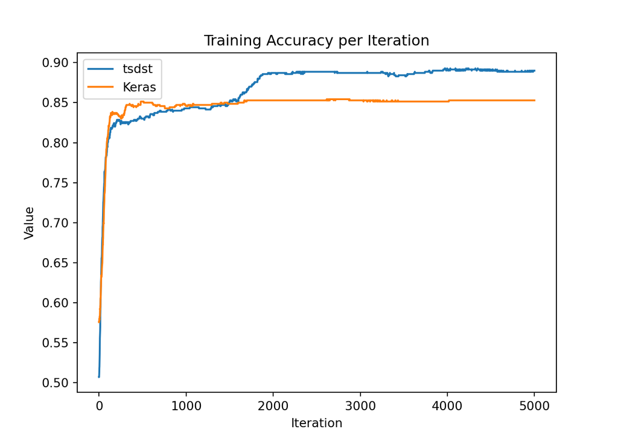

```python
plt.title("Training Accuracy per Iteration")
plt.xlabel("Iteration")
plt.ylabel("Value")
plt.plot(nn.metric)
plt.plot(history.history['accuracy'])
plt.legend(["tsdst", "Keras"])
plt.show()
```

### 2.7.1 activations

A module for activation functions (and their derivatives) related to neural network layers. Eventually, each function will get it’s own section, but for now, I will just list them. The sub bullets are the functions that can be passed as strings to the `activation`, `cost`, or`derivative` keys of the model dictionary. The main bullets are the model dictionary keys that the functions can (or rather, should) be used with.

- cost (for the output layer only)
  - cross_entropy
  - cross_entropy_binary
  - mse
- activation
  - elu
  - relu (using the alpha parameter, this is also leaky relu)
  - selu
  - gelu
  - gelu_approx (a quicker approximation of gelu, accurate to ~1e-5)
  - gelu_speedy (very approximate, very speedy)
  - sigmoid
  - softmax
- derivative
  - elu_der
  - mse_linear_der
  - relu_der
  - selu_der
  - gelu_der
  - gelu_speedy_der (derivative for gelu_speedy)
  - softmax_cross_entropy_der

The following exist as reference, but are not meant to be used in the model dictionary.

- cross_entropy_der
- cross_entropy_binary_der
- linear_der
- mse_der
- sigmoid_der
- softmax_cross_entropy_der_fullmath
- softmax_der
- softmax_oneout

### 2.7.2 initializers

Common functions to initialize layers in Neural Networks. These can be passed as strings to the `initializer` key in the model dictionary.

- he_normal
- he_uniform
- lecun_normal
- lecun_uniform
- random
- xavier_normal (also known as glorot normal)
- xavier_uniform (also known as glorot uniform)

### 2.7.3 model

#### 2.7.3.1 NeuralNetwork

This is a class for instantiating and running a neural network. It has the same form as an sklearn model.

##### 2.7.3.1.1 __init__

The constructor for the NeuralNetwork class.

```
Parameters
----------
model : dict
    A dictionary containing the model components, layers, and other
    specifications. The dictionary should have the following general
    structure:
        {
         'hidden0': {'depth': 10,
                     'activation': 'relu',
                     'derivative': 'relu_der',
                     'activation_args': {},
                     'initializer': 'he_uniform',
                     'dropout_keep_prob': 1,
                     'lambda': {'Weight': 0,
                               'activity': 0,
                               'bias': 0
                              },
                    'lp_norm': {'Weight': 2,
                               'activity': 2,
                               'bias': 2
                              },
                    'use_batch_norm': False
                     },
         'output': {'activation': 'softmax',
                    'activation_args': {},
                    'cost': 'cross_entropy',
                    'cost_args': {},
                    'derivative': 'softmax_cross_entropy_der',
                    'derivative_args': {},
                    'initializer': 'xavier_normal',
                    'evaluation_metric': 'accuracy',
                    'lambda': {'Weight': 0,
                               'activity': 0,
                               'bias': 0
                              },
                    'lp_norm': {'Weight': 2,
                               'activity': 2,
                               'bias': 2
                              },
                    'use_batch_norm': False
```

[output cut: 141 more lines]

```
    the true Y values and the predicted y values as the first two
    arguments of the function.
    The default is 'accuracy'.
shuffle : bool, optional
    Shuffle the training set before training. The default is False.
print_cost : bool, optional
    Print the cost (and possibly another metric) at each eval_step.
    The default is True.
random_state : int, optional
    The random state of the process (for reproducibility).
    The default is 42.

Returns
-------
None.
```

##### 2.7.3.1.2 backward_prop

The backward propagation step.

```
Parameters
----------
X : numpy array
    The input data.
Y : numpy array
    The true Y values.
wb : dict
    A dictionary of the weights/biases for each layer.
zs : dict
    A dictionary of the linearly (affine transform) activated values
    for each layer.
batch_norm : dict
    A dictionary containing the initial (or previous) batch norm
    results.
hzs : dict
    A dictionary of the fully activated values for each layer
dropout : dict
    A dictionary of the dropout status for each layer.

Returns
-------
dwdb : dict
    A dictionary of the gradients with respect to the weights and
    biases.
```

##### 2.7.3.1.3 draw_predicted_samples

Draws predictive samples for each observation from the distribution created by using dropout.

```
Parameters
----------
X : numpy array
    The input data.
n_samples : int, optional
    The number of samples to draw. The default is 1000.
n_outputs : int, optional
    The number of outputs or classes in Y. The default is 1.

Returns
-------
draws : numpy array
    The sampled predicted values.
```

##### 2.7.3.1.4 fit

Fits the Neural Network.

```
Parameters
----------
X : numpy array
    The input data.
Y : numpy array
    The true Y values.

Returns
-------
self
    The fitted model.
```

##### 2.7.3.1.5 forward_prop

The forward propagation step

```
Parameters
----------
X : numpy array
    The input data.
wb : dict
    A dictionary of the weights/biases for each layer.
batch_norm : dict
    A dictionary containing the initial (or previous) batch norm
    results.
train : bool, optional
    Whether the forward propagation method is being used to train or
    calculate the network in it's current state.
    The default is True.
sample : bool, optional
    Whether or not the forward propagation is being used to generate
    random smaples of the output from the distribution created using
    dropout. The default is False.

Returns
-------
hz : numpy array
    The final predicted output.
zs : dict
    A dictionary of the linearly (affine transform) activated values
    for each layer.
batch_norm : dict
    A dictionary containing the initial (or previous) batch norm
    results.
hzs : dict
    A dictionary of the fully activated values for each layer
dropout : dict
    A dictionary of the dropout status for each layer.
regularizers : dict
    A dictionary of the regularization status for each layer.
```

##### 2.7.3.1.6 initialize_wb

Initialize the network.

```
Parameters
----------
X : numpy array
    The input data.

Returns
-------
wb_list : dict
    A dictionary of the weights/biases for each layer.
```

##### 2.7.3.1.7 predict

Predict the Y values based on the input X.

```
Parameters
----------
X : numpy array
    The input data.

Returns
-------
hz : numpy array
    The predicted Y values.
```

##### 2.7.3.1.8 score

A method to score/test the model based on the inputs X, y. This can be a custom function or called with a string from something built-in.

```
Parameters
----------
X : numpy array
    The input data.
y : numpy array
    The true Y values.

Returns
-------
float or numpy array
    The score result for X, y.
```

### 2.7.4 optimizers

The following list contains the current optimizers available (passed as the `optimizer` argument in the class constructor).

- adam
- gd (gradient descent)

## 2.8 tsdst.optimization

Contains functions for optimization.

### 2.8.1 AdaptiveNMorBrent

An adaptive Nelder-Mead method for finding the max/min of functions. This is good for high-dimensional optimization problems. This is similar to scipy.optimize.minimize (see (Community, n.d.)). The default behavior is minimization. For maximization, pass the negative of `fun`. In one dimension, it performs the Brent method (see (Gao and Han 2012) and (Brent 1973)).

This function is notably slower than scipy.optimize.minimize. It was originally created because the author was having issues passing certain types of arguments to the scipy version of the function.

The options for this algorithm are passed as a dictionary and are defined as follows:

| Option | Default Value | Type |
| --- | --- | --- |
| dom_tol | 1.00e-08 | float |
| max_iter | 10000 | int |
| bounds | [-10000.0, 10000.0] | list(float), np.array(float), tuple(float) |
| fun_tol | 1.00e-08 | float |

Note that in the Brent method, `fun_tol` is not used, and in the NM method, `bounds` is not used.

```
Parameters
----------
fun : function
    The function to find the roots of.
start : numpy array
    The starting values for the optimization. Must be equal in length to
    the number of parameters being optimized.
opt : dict, optional
    Optional arguments for the optimization. The default is None.
print_ : bool, optional
    Print Results. The default is True.
fun_args : dict
    Optional arguments to pass to fun.

Raises
------
ValueError
    Raised if there are invalid bounds, or no valid root.
TypeError
    Raised if bounds is not a valid type.

Returns
-------
final_res : dict
    A dictionary containing the results.
```

```python
import numpy as np
from tsdst.optimization import AdaptiveNMorBrent


def gaussian(params, data):
    '''
    A gaussian likelihood.

    Parameters
    ----------
    params : numpy array
        The parameters of the distribution to be sampled in mcmc.
    data : numpy array
        The observed data.

    Returns
    -------
    like : float
        Negative Likelihood density.
    '''
    mu = params[0]
    sigma = params[1]

    like = np.sum((-0.5*np.log(2*np.pi) - np.log(sigma) - 0.5*((data - mu) / sigma)**2))

    return -like


X = np.random.normal(size=(100,), loc=100, scale=10)
start = np.random.uniform(size=(2,))

res = AdaptiveNMorBrent(start=start, fun=gaussian, opt=None, print_=True,
                        fun_args={'data': X})
```

```
Final Results
 {'Parameters': array([102.27762907,  10.50862907]), 'Final Function Value': 377.1135278709032, 'Domain Tolerances': array([4.26956773e-09, 4.80794377e-09]), 'Function Value Tolerance': 5.684341886080802e-14, 'Iterations': 107, 'Message': 'Successful', 'Method': 'NM'}
```

### 2.8.2 Brent_1DRoot

Evaluates the roots of a function using Brent’s method (see (Brent 1973)). This function is meant to be used with the signIntervals function.

The options for this algorithm are passed as a dictionary and are defined as follows:

| Option | Default Value | Type |
| --- | --- | --- |
| dom_tol | 1.00e-08 | float |
| max_iter | 10000 | int |
| bounds | [-10000.0, 10000.0] | list(float), np.array(float), tuple(float) |
| fun_tol | 1.00e-08 | float |

Example:

```python
from tsdst.optimization import signIntervals, Brent_1DRoot

def func(x):
  return x**2 - 5

bds = signIntervals(func)
for i in bds:
    Brent_1DRoot(func, opt={'bounds': i})
```

```
Inputs:
 {'bounds': (-50.0, -2.230000000009504)}

Final Results
 {'root': -2.2360679774997867, 'Final Function Value': -1.3322676295501878e-14, 'Domain Tolerances': 3.552713678800501e-15, 'Iterations': 22, 'a:b:s': (-2.2360679774997867, -2.2360679774997902, -2.2360679774997902)}
{'root': -2.2360679774997867, 'Final Function Value': -1.3322676295501878e-14, 'Domain Tolerances': 3.552713678800501e-15, 'Iterations': 22, 'a:b:s': (-2.2360679774997867, -2.2360679774997902, -2.2360679774997902)}
Inputs:
 {'bounds': (-2.230000000009504, 2.2399999999896067)}

Final Results
 {'root': 2.236067982149955, 'Final Function Value': 2.079617100747555e-08, 'Domain Tolerances': 6.981950573248241e-09, 'Iterations': 29, 'a:b:s': (2.236067982149955, 2.2360679751680044, 2.2360679751680044)}
{'root': 2.236067982149955, 'Final Function Value': 2.079617100747555e-08, 'Domain Tolerances': 6.981950573248241e-09, 'Iterations': 29, 'a:b:s': (2.236067982149955, 2.2360679751680044, 2.2360679751680044)}
```

### 2.8.3 max_like

`max_like` evaluates the maximum likelihood of a numeric function. It also computes the standard errors from the observed fisher information criteria. It uses AdaptiveNMorBrent as the optimization function. It returns the MLE of the parameters, the standard error for each parameter, and a matrix representing the confidence intervals of the parameters (The author can’t remember if the rows or the columns separate the parameters…).

The options for this algorithm are passed as a dictionary and are defined as follows:

| Option | Default Value | Type |
| --- | --- | --- |
| dom_tol | 1.00e-08 | float |
| maxiter | 500 | int |

```python
import numpy as np
from tsdst.optimization import max_like


def gaussian(params, data):
    '''
    A gaussian likelihood.

    Parameters
    ----------
    params : numpy array
        The parameters of the distribution to be sampled in mcmc.
    data : numpy array
        The observed data.

    Returns
    -------
    like : float
        Negative Likelihood density.
    '''
    mu = params[0]
    sigma = params[1]

    like = np.sum((-0.5*np.log(2*np.pi) - np.log(sigma) - 0.5*((data - mu) / sigma)**2))

    return -like


X = np.random.normal(size=(100,), loc=100, scale=10)
start = np.random.uniform(size=(2,))

res = max_like(start=start, lf=gaussian, opt=None, print_=False,
               like_args={'data': X})

print('MLE Estimates: ', res[0])
```

```
MLE Estimates:  [98.05273366  9.7380848 ]
```

```python
print('Standard Error: ', res[1])
```

```
Standard Error:  [0.97380848 0.68858656]
```

```python
print('95% CI: ', res[2])
```

```
95% CI:  [[96.14410411 99.96136321]
 [ 8.38847995 11.08768966]]
```

### 2.8.4 signIntervals

This returns a list of tuples, where each tuple is a range of values that have the same sign. This helps Brent_1DRoot find the points where $f(x) = 0$

```
Parameters
----------
fun : function
    The function to find the roots of.
lower : float, optional
    The minimum value to investigate. The default is -50.
upper : float, optional
    The maximum value to investigate. The default is 50.
step : float, optional
    The interval between values in (lower, upper) to investigate.
    The default is 0.01.
fun_args : dict
    Optional arguments to pass to fun.

Returns
-------
bounds : list
    A list of tuples containing the upper and lower bounds of possible
    roots.
```

```python
signIntervals(fun, lower=-50, upper=50, step=0.01, *args)
```

## 2.9 tsdst.parallel

Methods for parallel programming

### 2.9.1 p_prog_simp

Parallel Progress bar.

Note: it is a known bug for this function to fail while using sypder. I have not been able to discover why, or provide a fix. If you run a script with this function from the console (or possibly jupyter), it should run just fine.

It is also known that using threads may be buggy for this function. It was intended to be used only on processes, but I included the thread option as a supplement to experiment with later. It is not guarenteed to work.

```
Parameters
----------
args : dict
    Dictionary of stationary arguments (i.e. the arguments that are
    constant throughout the loop).
loop_args : list
    A list of dictionaries that contain the arguments that may change at
    any point during the loop (this is the iterator, and any additional
    arguments that may have different values at different stages of the
    loop).
function : function
    The function being being processed in the loop (args and loop args will
    be passed to this function).
n_jobs : int, optional
    The number of parallel processes to run. The default is 2.

Returns
-------
list
    Returns a list of the function outputs for each iteration.
```

```python
import numpy as np
from tsdst.parallel import p_prog_simp

def superpower(x, a, b):
    return x**a - x**b

X = np.random.normal(size=(10,))
a = 3
b = 2

args = {'a': a, 'b': b}
loop_args = [{'x': xx} for xx in X]
p_prog_simp(args=args, loop_args=loop_args, function=superpower, n_jobs=2,
            verbose=True, use_threads=False)
```

[output not shown]

### 2.9.2 p_prog_simp_memorySafe

Parallel Progress bar. The same as p_prog_simp, except it is more explicit in it’s definition. This function was developed to try and limit memory consumption for parallel operations. I’m not 100% sure if it accomplishes that… More testing is needed.

```
Parameters
----------
args : dict
    Dictionary of stationary arguments (i.e. the arguments that are
    constant throughout the loop).
loop_args : list
    A list of dictionaries that contain the arguments that may change at
    any point during the loop (this is the iterator, and any additional
    arguments that may have different values at different stages of the
    loop).
function : function
    The function being being processed in the loop (args and loop args will
    be passed to this function).
n_jobs : int, optional
    The number of parallel processes to run. The default is 2.

Returns
-------
list
    Returns a list of the function outputs for each iteration.
```

## 2.10 tsdst.quick_analysis

### 2.10.1 QuickAnalysis

A class for performing a quick sweep of the data. Helps establish a baseline model to get started with, as well as quickly identify potentially useful features.

#### 2.10.1.1 initialize

```python
QuickAnalysis(train, holdout, target_var, low_memory=False,
              name="QuickAnalysis")
```

#### 2.10.1.2 RunFullAnalysis

```
Percent: [#-------------------] 6.25% iter: 1/16 Working... Elapsed: 00:00:00, Estimated: 00:00:01
Percent: [##------------------] 12.50% iter: 2/16 Working... Elapsed: 00:00:00, Estimated: 00:00:01
Percent: [####----------------] 18.75% iter: 3/16 Working... Elapsed: 00:00:00, Estimated: 00:00:01
Percent: [#####---------------] 25.00% iter: 4/16 Working... Elapsed: 00:00:00, Estimated: 00:00:01
Percent: [######--------------] 31.25% iter: 5/16 Working... Elapsed: 00:00:00, Estimated: 00:00:01
Percent: [########------------] 37.50% iter: 6/16 Working... Elapsed: 00:00:00, Estimated: 00:00:01
Percent: [#########-----------] 43.75% iter: 7/16 Working... Elapsed: 00:00:00, Estimated: 00:00:01
Percent: [##########----------] 50.00% iter: 8/16 Working... Elapsed: 00:00:01, Estimated: 00:00:01
Percent: [###########---------] 56.25% iter: 9/16 Working... Elapsed: 00:00:01, Estimated: 00:00:00
Percent: [############--------] 62.50% iter: 10/16 Working... Elapsed: 00:00:01, Estimated: 00:00:00
Percent: [##############------] 68.75% iter: 11/16 Working... Elapsed: 00:00:01, Estimated: 00:00:00
Percent: [###############-----] 75.00% iter: 12/16 Working... Elapsed: 00:00:01, Estimated: 00:00:00
Percent: [################----] 81.25% iter: 13/16 Working... Elapsed: 00:00:01, Estimated: 00:00:00
Percent: [##################--] 87.50% iter: 14/16 Working... Elapsed: 00:00:01, Estimated: 00:00:00
Percent: [###################-] 93.75% iter: 15/16 Working... Elapsed: 00:00:01, Estimated: 00:00:00
Percent: [####################] 100.00% iter: 16/16 Finished!... Elapsed: 00:00:01, Estimated: 00:00:00
```

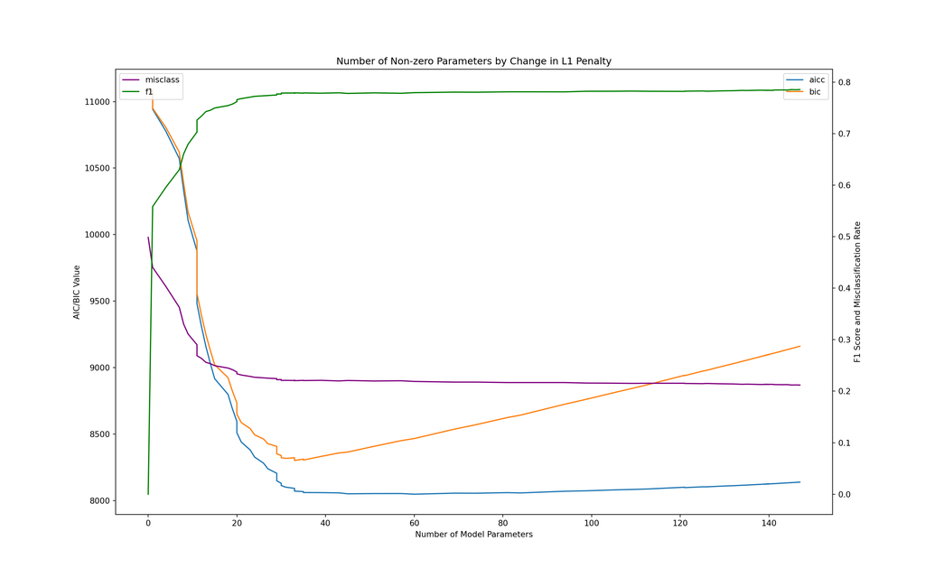

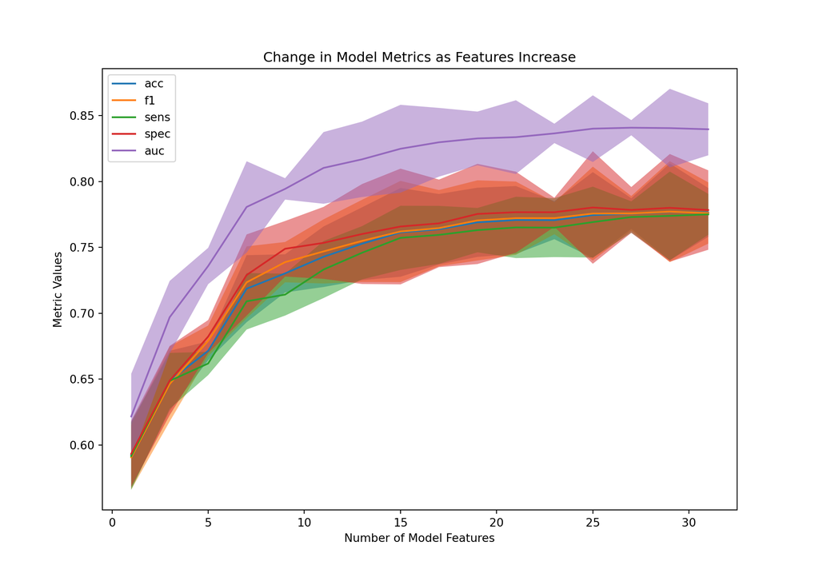

```python
import numpy as np
import pandas as pd
import seaborn as sns
from matplotlib import pyplot as plt
from sklearn.datasets import make_classification
from sklearn.linear_model import LogisticRegression
from sklearn.model_selection import train_test_split
from timeit import default_timer as dt

from tsdst.quick_analysis import QuickAnalysis

X, y = make_classification(n_samples=10000, n_features=150, flip_y=0.2,
                           n_informative=40, random_state=42)

X_train, X_test, y_train, y_test = train_test_split(X, y, test_size=0.2, random_state=42)
XY_train = pd.concat((pd.DataFrame(X_train, columns=['V' + str(i) for i in range(X.shape[1])]),
                      pd.DataFrame(y_train.reshape(-1, 1),
                                   columns=['y'])),
                      axis=1)
XY_hold = pd.concat((pd.DataFrame(X_test, columns=['V' + str(i) for i in range(X.shape[1])]),
                      pd.DataFrame(y_test.reshape(-1, 1),
                                   columns=['y'])),
                      axis=1)

qa = QuickAnalysis(train=XY_train, holdout=XY_hold, target_var='y', low_memory=False,
                   name="QuickAnalysis")

qa.RunFullAnalysis(freshStart=True, downsample=False, dropCols=None,
                   dropCor=True, corr_cutoff=0.9, dropVar=True,
                   dropVarTol=0.001, cv_iterations=5,
                   random_state=123, default_penalty=0.01, verbose=False,
                   try_parallel=False, for_stride=2, reduce_features_by=30,
                   num_cs=100, red_metric='bic', red_log_low=-5,
                   red_log_high=0, n_jobs=1, remove_msg=True,
                   chunk=False)
```

## 2.11 tsdst.sampling

Methods for sampling datasets.

### 2.11.1 downSample

In a low base-rate classification problem, it is sometimes advantageous to downsample the majority class until the classes are balanced (or close enough). This is done by randomly removing a proportion of observations from only the majority class.

```
Parameters
----------
data : pandas dataframe
    The design or feature matrix (with response).
target_var : str
    The target or reponse variable.
majority : int, optional
    Value of the majority class. The default is 0.
minority : int, optional
    Value of the minority class. The default is 1.
bal : float, optional
    The class balance after downsampling. The default is 0.5.
random_state : int, optional
    The random seed for the process. The default is 123.

Returns
-------
data_sub : pandas dataframe
    The downsampled data.
```

```python
import numpy as np
import pandas as pd
from sklearn.datasets import make_classification

from tsdst.sampling import downSample


X, y = make_classification(n_samples=1000, n_features=8, flip_y=0.2, random_state=42)

XY = pd.concat((pd.DataFrame(X, columns=['V' + str(i) for i in range(X.shape[1])]),
                      pd.DataFrame(y.reshape(-1, 1),
                                   columns=['y'])),
                      axis=1)

# Create artificial minority class for example
XY_0 = XY[XY['y'] == 0]
XY_1 = XY[XY['y'] == 1].loc[np.random.choice(XY[XY['y'] == 1].index, 10), :]

XY_n = pd.concat((XY_0, XY_1))

XY_ds = downSample(XY_n, target_var='y')
```

### 2.11.2 genRandSampFromDF

Creates a Random sample of observations (rows) from a Dataframe (data). If `replace=True`, this function can be used for bootstrap samples.

```
Parameters
----------
data : pandas dataframe
    The design or feature matrix (with response).
sampSize : int
    Number of somples to return.
replace : bool, optional
    Sample with replacement. The default is False.
random_state : int, optional
    The random seed for the process. The default is None.

Returns
-------
rand : pandas dataframe
    The randomly sampled data.
```

```python
import numpy as np
import pandas as pd
from sklearn.datasets import make_classification

from tsdst.sampling import genRandSampFromDF


X, y = make_classification(n_samples=1000, n_features=8, flip_y=0.2, random_state=42)

XY = pd.concat((pd.DataFrame(X, columns=['V' + str(i) for i in range(X.shape[1])]),
                      pd.DataFrame(y.reshape(-1, 1),
                                   columns=['y'])),
                      axis=1)

XY_rs = genRandSampFromDF(XY, 100)
```

### 2.11.3 latinHypercube1D

This function computes a latin hypercube sample for a 1-dimensional object. This is helpful in reducing the dimension of an MCMC chain (or other dataset) while still maintaining a near-random sample of the target distribution.

In the case of data used for modeling (i.e. $Y \sim X$), The author has found success in reducing the number of samples using this method (where `sort_col=Y_col_location`), while still maintaing overall shape/performance of the model. This is particularily useful in tuning the hyperparameters of models that may take a long time to converge (such as Support Vector Machines).

Setting `stratified=True` ensures that (in classification examples) the class balance remains the same in the sub-sample. Otherwise, you may be slightly under or over representated in one of the classes. In cases where there is not an even division of $\frac{N_{Observations}}{N_{Samples}}$, `bin_placement="random"` will distribute the bins randomly. For example, if I have 13 observations and desire 5 samples, then when `stratified=False`, `bin_location_and_size = [3, 3, 3, 2, 2]`. When `stratified=True` and `bin_placement="spaced"`, `bin_location_and_size = [3, 2, 3, 2, 3]`. If `bin_placement="random"`, then the location of the bins is chosen at random.

```
Parameters
----------
data : numpy array or pandas dataframe
    The design or feature matrix (with response).
sampleSize : int
    The number of samples to return.
random_state : int, optional
    The random seed of the process. The default is None.
shuffle_after : bool, optional
    Shuffle the results after being sampled. The default is True.
sort_ : bool, optional
    Sort the data (only set to False if sending presorted data).
    The default is True.
sort_method : str, optional
    Numpy sort method. The default is "quicksort".
sort_cols : list, optional
    The columns to include in the sorting. The default is None.
stratified : bool, optional
    Create a stratified sample. The default is True.
bin_placement : str, optional
    Method for placing the edges on the sampling bins.
    The default is "random".
verbose : bool, optional
    Print the results of the process. The default is False.

Raises
------
ValueError
    Raised if invalid bin_plcement is passed.

Returns
-------
LHC : pandas dataframe or numpy array
    The samples.
```

```python
import numpy as np
import pandas as pd
from sklearn.datasets import make_classification

from tsdst.sampling import latinHypercube1D


X, y = make_classification(n_samples=10000, n_features=8, flip_y=0.2, random_state=42)

XY = pd.concat((pd.DataFrame(X, columns=['V' + str(i) for i in range(X.shape[1])]),
                      pd.DataFrame(y.reshape(-1, 1),
                                   columns=['y'])),
                      axis=1)

XY_lhc = latinHypercube1D(XY, sampleSize=1000, random_state=42, shuffle_after=True,
                          sort_=True, sort_method="quicksort", sort_cols=None,
                          stratified=True, bin_placement="random", verbose=False)
```

## 2.12 tsdst.tmath

Math functions.

### 2.12.1 biserial_rank_corr

Biserial Rank Correlation.

```
Parameters
----------
x : numpy array
    Values to be evaluated. Either a single group, or an array containing
    both group values if y_is == 'groups'
y : numpy array
    Values to be evaluated against x, or, if y_is == 'groups',
    then y is a boolean value indicating which group the values
    of x belong to.
y_is : bool, optional
    Whether or not y is itself a group of values, or an indicator variable
    for identifying the groups within x. The default is 'groups'.

Returns
-------
r : float
    Biserial rank correlation.
```

```python
import numpy as np
from tsdst.tmath import biserial_rank_corr

X = np.random.normal(size=100)
Y = np.random.uniform(size=100)

biserial_rank_corr(x=X, y=Y, y_is="not_groups")
```

```
0.32119999999999993
```

### 2.12.2 corr

Mimics the R cor function to calculate correlations.

```
Parameters
----------
x : numpy array or pandas dataframe
    Either a matrix (to calculate correlations across columns) or a 1D
    array to compare with y.
y : numpy array or pandas series, optional
    A 1D array to compare with a 1D x, or None if x is a matrix.
    The default is None.
method : str, optional
    Type of correlation to compute. The default is 'pearson'.

Raises
------
ValueError
    Raised if method provided is invalid.

Returns
-------
numpy array
    Array containing the correlation.
```

```python
import numpy as np
from tsdst.tmath import corr


X = np.array([[1, 2], [1, 5], [6, 2], [1, 3], [4, 4], [6, 7]])

print('Numpy Pearson Calculation: ', np.corrcoef(X, rowvar=False))
```

```
Numpy Pearson Calculation:  [[1.         0.29740165]
 [0.29740165 1.        ]]
```

```python
print('corr Pearson Calculation: ', corr(X))
```

```
corr Pearson Calculation:  [[1.         0.29740165]
 [0.29740165 1.        ]]
```

```python
print('corr Spearman Calculation: ', corr(X, method='spearman'))
```

```
corr Spearman Calculation:  [[1.         0.17221168]
 [0.17221168 1.        ]]
```

```python
print('corr Kendall Calculation: ', corr(X, method='kendall'))
```

```
corr Kendall Calculation:  [[1.         0.16116459]
 [0.16116459 1.        ]]
```

### 2.12.3 cov2cor

Translation of R’s cov2cor function

```
Parameters
----------
V : numpy array
    Covariance matrix.

Returns
-------
R : numpy array
    Correlation matrix.
```

```python
import numpy as np
from tsdst.tmath import cov2cor


X = np.array([[1, 2], [1, 5], [6, 2], [1, 3], [4, 4], [6, 7]])
X_cor = np.corrcoef(X, rowvar=False)
X_cov = np.cov(X, rowvar=False)
X_cor_2 = cov2cor(X_cov)

print('Numpy Correlation Calculation: ', X_cor)
```

```
Numpy Correlation Calculation:  [[1.         0.29740165]
 [0.29740165 1.        ]]
```

```python
print('cov2cor Calculation: ', X_cor_2)
```

```
cov2cor Calculation:  [[1.         0.29740165]
 [0.29740165 1.        ]]
```

### 2.12.4 mahalanobis

Calculates the Mahalanobis distance of a dataframe/matrix. If `produce="squared"`, it returns the squared Mahalanobis distance. If `produce="leverage"`, it returns the leverage statistic.

The Mahalanobis distance is the distance of a test point from the center of mass divided by the width of the ellipsoid in the direction of the test point. In other words, it is a multidimensional generalization of the Z-score statistic, and represents how many “standard deviations” the test point is from the center (or dimensional means, i.e. for columns $i = 1,2,...,m$, $\pmb\mu_{center} = (\mu_1, \mu_2, ..., \mu_m)$. Mahalanobis distance is related to Euclidean distance, but it better suited for non-standard shapes (i.e. non-normal, non-linear, etc.). This is because Mahalanobis distance accounts for the fact that a set of points may be more variable in one dimension and less variable in another. This means that an extreme value may not be detected using a Euclidean distance measure because the spread of the data is not equal amoung dimensions ($var(X_1) \ne var(X_2)$). Mahalanobis distance uses the covariance matrix in its calculation to acocunt for this, where the covariance matrix contains information about the spread of each variable (i.e. the variance on the diagonals) and about directional similarity between variables, or the tendency for two variables to move in the same direction (i.e. the covariance on the off diagonals). If the covaraince matrix is equal to the identity matrix (and the covariance matrix is substituted and simplified in the equation), then Mahalanobis distance simplifies to the Euclidean distance. If the covariance matrix is diagonal, then the Mahalanobis distance simplifies to a standardized version of the Euclidean distance.

The math is shown below.

Let:

- $n$ be the number of observations
- $D_{n \times 1}$ be the Mahalanobis distance
- $H_{n \times 1}$ be the leverage statistic
- $X_{n \times m}$ be the data of interest
- $\mu_{X}$ be the column means of $X$

Then:

$$D = \sqrt{diag((X - \mu_{X}) (cov(X, X)^{-1})(X - \mu_{X})^T)}$$

or, sometimes more efficiently calculated:

$$D = \sqrt{rowsum((X - \mu_{X}) (cov(X, X)^{-1}) * (X - \mu_{X}))}$$

where $* (X - \mu_{X})$ represents element-wise multiplication. $H$, or leverage, can then be derived as follows:

$$H = \frac{D^2}{n - 1} + \frac{1}{n}$$

It may also be useful to note that if the columns of $X$ are centered (i.e. for columns $i = 1,2,...,m$, $X_i := X_i - \mu_{X_i}$), then:

$$\textbf{H} = X (X^{T} X)^{-1}X^T$$

where the diagonal of $\textbf{H}$ ($[\textbf{H}]_{ii} = H_i$) is the leverage statistic for the $i$-th observation. Note the similarities to the least squares solution in linear regression. Also note that centering $X$ is only required since the $X$ in
$$\textbf{H} = X (X^{T} X)^{-1}X^T$$
typically contains an intercept column (the corresponding $\beta_0$ column of ones added to $X$ in the regression equation). If this column of ones is missing, then centering is required before calculating leverage from $X$ using the diagonal of $X (X^{T} X)^{-1}X^T$. Otherwise, the two methods for calculating leverage are equivalent. $\textbf{H}$ is sometimes called the hat matrix because it is typically displayed with a hat such that $\hat{y} = \hat{H}y = [X (X^{T} X)^{-1}X^T]y = X\hat{\beta}$, where $\hat{y}$ represents the predicted values in linear regression. $\textbf{H}$ is also called the projection matrix. See appendix for more details.

```python
mahalanobis(data, produce=None)
```

### 2.12.5 mann_whitney

Mann-Whitney sum-rank test.

```
Parameters
----------
x : numpy array
    Values to be evaluated. Either a single group, or an array containing
    both group values if y_is == 'groups'
y : numpy array
    Values to be evaluated against x, or, if y_is == 'groups',
    then y is a boolean value indicating which group the values
    of x belong to.
y_is : bool, optional
    Whether or not y is itself a group of values, or an indicator variable
    for identifying the groups within x. The default is 'groups'.

Returns
-------
res : dict
    The results of the Mann-Whitney test.
```

```python
import numpy as np
from tsdst.tmath import mann_whitney

X = np.random.normal(size=10)
Y = np.random.uniform(size=10)

mann_whitney(x=X, y=Y, y_is="not_groups")
```

```
{'U1': 22.0, 'U2': 78.0, 'n1': 10, 'n2': 10, 'rank_group1': array([ 7.,  5.,  4.,  1.,  3., 12.,  6.,  2., 17., 20.]), 'rank_group2': array([13., 14.,  9.,  8., 19., 11., 10., 18., 15., 16.]), 'sum_ranks_g1': 77.0, 'sum_ranks_g2': 133.0, 'max_U': 'U2'}
```

### 2.12.6 mode_histogram

Calculates the mode using data provided from a histogram. Created because calculating mode from KDE estimate can be slow.

```
Parameters
----------
data : numpy array
    Array of data to calculate the mode from.
delta : int, optional
    Used to calculate histogram bin width. The default is 75.
dataMax_thres : float, optional
    Max value to consider in hisogram calculation (for the right edge).
    The default is 1e9.
median_thres : float, optional
    Used to limit the center of the distribution, if median is a really
    high number. The default is None.

Returns
-------
float
    The mode of the array.
hist : numpy array
    The histogram used to calculate mode.
```

```python
import numpy as np
from timeit import default_timer as dt

from tsdst.tmath import mode_histogram, mode_kde
from tsdst.utils import print_time


X = np.random.normal(size=10000)
t0 = dt()
md_hist = mode_histogram(X)
t1 = dt()
md_kde = mode_kde(X)
t2 = dt()

print_time("mode_histogram vaule: " + str(md_hist) + " , mode_histogram time: ", ts=t0, te=t1, display_realtime=False)
```

```
mode_histogram vaule: 0.17741748846444985 , mode_histogram time: 00:00:00
```

```python
print_time("mode_kde vaule: " + str(md_kde) + " , mode_histogram time: ", ts=t1, te=t2, display_realtime=False)
```

```
mode_kde vaule: 0.09499988349703703 , mode_histogram time: 00:00:01
```

### 2.12.7 mode_kde

Calculate mode from gaussian kernel density estimate (using scipy gaussian_pde).

```
Parameters
----------
data : numpy array
    Array to calculate mode from.
kde_args : dict
    A dictionary containing arguments for gaussian_kde (scipy)

Returns
-------
mode :
    A numeric value, which is the mode.
```

```python
import numpy as np
from timeit import default_timer as dt

from tsdst.tmath import mode_histogram, mode_kde
from tsdst.utils import print_time


X = np.random.normal(size=10000)
t0 = dt()
md_hist = mode_histogram(X)
t1 = dt()
md_kde = mode_kde(X)
t2 = dt()

print_time("mode_histogram vaule: " + str(md_hist) + " , mode_histogram time: ",
           ts=t0, te=t1, display_realtime=False)
```

```
mode_histogram vaule: -0.16494525420944756 , mode_histogram time: 00:00:00
```

```python
print_time("mode_kde vaule: " + str(md_kde) + " , mode_histogram time: ",
           ts=t1, te=t2, display_realtime=False)
```

```
mode_kde vaule: -0.05879483955525934 , mode_histogram time: 00:00:01
```

### 2.12.8 norm

Calculate $L_P$ norm of a vector.

When `p = 0`, the function returns the number of elements (sometimes referred to as the $L_0$ norm, though not officially). Otherwise, the norm takes the general form of $||x||_p = (\sum_{i=1}^n|x_{i}|^{p})^{\frac{1}{p}}$.

Regression applications with L2 penalty often dismiss the full norm, particularly in L2 regularization. I’ll note here that there is no added benefit to using norms higher than 2 in those cases. Odd norms (L3 and higher) are non-differentiable at the origin and they behave the same as L1. L4 and higher norms have the same local meaning are differentiable, thus providing no additional useful information in regularization.

```
Parameters
----------
data : numpy array
    A 1D numpy array of values.
p : int
    The LP norm specification (1,2,3, ...).
use_expo : bool, optional
    Use final exponentiation in norm calculation. Particularily for the
    L2 norm, regularization applications will use the square of the norm,
    so in the L2 case, when use_expo=True, a 1/p exponent is
    added to the final result.

Returns
-------
numeric
    Value of the LP norm on the vector.

'''
```

### 2.12.9 norm_der

Calculates the LP norm derivative of a vector. See norm for more details

```
Parameters
----------
data : numpy array
    A 1D numpy array of values.
p : int
    The LP norm specification (1,2,3, ...).
use_expo : bool, optional
    Use final exponentiation in norm calculation. Particularily for the
    L2 norm, regularization applications will use the square of the norm,
    so in the L2 case, when use_expo=True, a 1/p exponent is
    added to the final result.

Returns
-------
numeric
    Value of the LP norm derivative on the vector.
```

### 2.12.10 percentIncrease

Calculates the percent increase between two numbers.

```
Parameters
----------
old : numeric
    The old number.
new : numeric
    The new number.

Returns
-------
numeric
    The percent increase (as a decimal).
```

```python
from tsdst.tmath import percentIncrease


old = 25
new = 45
percentIncrease(old=old, new=new)
```

```
0.8
```

### 2.12.11 powerset

Create the powerset (all possible combinations) of a list.

[output not shown]

```python
from tsdst.tmath import powerset


mylist = [1,2,3,4]
powerset(mylist)
```

```
<itertools.chain object at 0x000000000D076FA0>
```

### 2.12.12 rank

Rank items in an array. Using the ‘first’ method, which ranks ties using the order of appearance. For rank functionality similar to R, see [scipy’s `rankdata`](https://docs.scipy.org/doc/scipy/reference/generated/scipy.stats.rankdata.html) function (which can be imported from this module for convenience).’

```
Parameters
----------
x : numpy array or array-like
    The array of values to be sorted.
small_rank_is_high_num : bool, optional
    Smallest rank value is the highest/largest number.
    The default is True.
rank_from_1 : bool, optional
    Use 1 as the top rank rather than 0. The default is True.

Returns
-------
rk : numpy array
    An array containing the ranks.
```

```python
from tsdst.tmath import rank


X = [27, 45, 10, 23, 91, 102]
rank(X)
```

```
array([4, 3, 6, 5, 2, 1], dtype=int64)
```

### 2.12.13 scaling

A scaling function to scale a single column or vector of data. It can perform min-max scaling and robust scaling of various forms. The values `a, b` convert the resulting array to the scale given by `a` and `b`. For example, in Min-Max Scaling, the range of scaled values is between 0 and 1, but can easily be adjusted to any other minimum and maximum value by setting `a, b`. `percentile` controls the amount `x` is scaled by when `scale=None` by obtaining an upper and lower value in the range of x. `ddof` is used when scale is provided either `np.var` or `np.std`. A general form of the function is provided below:

$$x := \frac{(b - a)(x - center)}{scale} + a$$

In this function, the default value for `scale` is $UQ - LQ$, where $UQ, LQ$ represent the upper and lower quartiles of x (defined by `percentile`), and the default values are 0 and 100% (or the min and max). The default value for `center` is the lower quartile. To have the function skip either centering or scaling for any configuration, set `center=0` or `scale=1`.

```
Parameters
----------
x : numpy array
    The data.
a : float, optional
    The minimum value desired. The default is 0.
b : float, optional
    The maximum value desired. The default is 1.
percentile : list or array-like, optional
    Provide percentile bounds on values. The default is (0, 100).
center : float or str, optional
    Either a value representing the centrality measure, or a string
    for the measure to be computed, either mean or median.
    If None, use the minimum of the percentile bounds.
    The default is None.
scale : float or str, optional
    Either a value representing the dispersion measure, or a string
    for the measure to be computed, either std (standard deviation),
    var (variance), or maxAbs.
    If None, use the absolute difference of the percentile bounds.
    The default is None.
ddof : int, optional
    Degrees of freedom for the variance/std. dev measure. The default is 0.

Raises
------
TypeError
    Raised if center is an invalid type.

Returns
-------
scaled : numpy array
    The scaled values.
```

Common configurations are provided in the following sections.

#### 2.12.13.1 Max Absolute Value

Calculation:

$$x := \frac{x}{\max{|x|}}$$

Function Inputs:

```python
scaling(X, center=0, scale="maxAbs")
```

#### 2.12.13.2 Min-Max Scaling

Calculation:

$$x := \frac{x - \min{x}}{\max{x} - \min{x}}$$

Function Inputs:

```python
scaling(X)
```

#### 2.12.13.3 Robust Scaler

This scaler can be used with any percentile range (that is equivalent distance from the center on both sides), but the most common is to use the IQR ranges (i.e. median for centering, and 25/75% for the scaling).

Calculation:

$m_x$: measure of center (such as the median) $UQ, LQ$: upper and lower quartile

$$x := \frac{x - m_{x}}{UQ_x - LQ_x}$$

Function Inputs:

```python
scaling(X, center="median", percentile=(25, 75))
```

#### 2.12.13.4 Standard Scaler

Calculation:

$$x := \frac{x - \mu_{x}}{\sigma_x}$$

Function Inputs:

```python
scaling(X, center="mean", scale="std")
```

## 2.13 tsdst.utils

General functions for various tasks.

### 2.13.1 check_dir

Check if a directory exists. If it doesn’t, create it.

```
Parameters
----------
directory : str
    Directory to check.
make : bool, optional
    Whether or not to create a missing directory. The default is True.
verbose : bool
    Print results.

Returns
-------
bool
    True if the directory exists.
```

### 2.13.2 dsn_getTable

Load data into python from a sql database.

Requires a DSN or connection string. Uses sqlAlchemy to make the connection, and closes the connection on completion. See [sqlAlchemy](https://docs.sqlalchemy.org/en/13/core/engines.html) for help building connection strings.

```
Parameters
----------
sql : str, or list
    A string containing the sql statement to be ran (It should be something
    that returns a table), or a list of sql statements to return multiple
    tables (tables are returned as a list of pandas dataframes, in this
    case).
user : str
    The username for the database application, if applicable.
dialect : str
    The database flavor (oracle, mysql, etc.)
dsn : str, optional
    Can either be a saved DSN from your computer, or a string that
    represents all the relevant information provided in a DSN.
    It can also be a host:port combination. See sqlalchemy
    documentation for more details.
pw : str, optional
    The password for the database application that matches the user
    specified, if applicable. If None or '', getpass will ask for a
    password. If there is no password, just leave it blank.
    The default is None.
create_engine_args : dict
    A dictionary containing arguments to be passed to sqlAlchemy's
    create_engine function.
read_sql_args : dict
    A dictionary containing arguments to be passed to pandas'
    read_sql function.

Returns
-------
data : pandas dataframe or list
    A dataframe (or list of dataframes) containing the returned data.
```

### 2.13.3 dsn_saveTable

Save pandas dataframe to database.

```
Parameters
----------
data : pandas dataframe
    The data to save to a table.
tableName : str
    The name of the table in the database.
user : str
    The username for the database application, if applicable.
dialect : str
    The database flavor (oracle, mysql, etc.)
dsn : str, optional
    Can either be a saved DSN from your computer, or a string that
    represents all the relevant information provided in a DSN.
    It can also be a host:port combination. See sqlalchemy
    documentation for more details.
pw : str, optional
    The password for the database application that matches the user
    specified, if applicable. If None or '', getpass will ask for a
    password. If there is no password, just leave it blank.
    The default is None.
create_engine_args : dict
    A dictionary containing arguments to be passed to sqlAlchemy's
    create_engine function. Default is {}
to_sql_args : dict
    A dictionary containing arguments to be passed to pandas'
    read_sql function. Default is {}

Returns
-------
None.
```

### 2.13.4 keyword_search

Searches a list of text arguments and returns a list that includes/excludes the list elements that contain the keywords.

```
Useful when searching for column names in a large dataframe, for example.

Parameters
----------
text_list : list
    List of string values.
include_keywords : list
    List of keywords to search for.
exclude_keywords : list, optional
    List of keywords that might be similar to include_keywords, but should
    be excluded nonetheless. The default is None.

Returns
-------
found_list : list
    Returns items from the original list that match the keywords.
```

```python
from tsdst.utils import keywordSearch


text_list = ['hi bye', 'joe', 'snakes', 'ol joe', 'hojo']
keywordSearch(text_list, 'jo')
```

```
['joe', 'ol joe', 'hojo']
```

### 2.13.5 infer_feature_type

Infer feature type of a column based on it’s `dytpe`. The inferred data types are `categorical`, `numeric`, or `date`.

```
Parameters
----------
X : dataframe or ndarray
    The dataframe containing columns whose datatype needs to be inferred.
n_unique : int
    The number of unique values to use as a cutoff for numeric columns,
    for example, if the number of unique values for a numeric column is
    greater than n_unique, consider it numeric. Default is None.

Returns:
--------
d_type : str
    String representation of the d_type
```

[numpy arrays.dtypes](https://numpy.org/doc/stable/reference/arrays.dtypes.html) reference table:

```
? : boolean
b : signed byte (sometimes interchangeable with boolean, it seems)
B : unsigned byte
i : signed integer
u : unsigned integer
f : float
c : complex float
m : timedelta
M : datetime
O : object
S : zero-terminated bytes
a : zero-terminated bytes
U : unicode string
V : raw data (void)
```

### 2.13.6 move_columns_to_end

Rearrange a pandas dataframe by moving a column (or list of columns) to the end of the dataframe.

```
Parameters
----------
data : pandas dataframe
    Data to rearrange.
col : str or list
    String containing one column to move, or list containing several.

Returns
-------
data : pandas dataframe
    Data with rearranged columns.
```

### 2.13.7 pretty_print_time

This function creates a pretty output (i.e. clock-like format HH:MM:SS.MS) of an arbitrary time (in seconds). Observe:

```
Parameters
----------
ts : float
    Start time (or elapsed time if te is None).
te : float, optional
    End time. The default is None.
decimals : int, optional
    The number of decimal places to use for tracking miliseconds.
    The default is 0

Returns
-------
pretty : str
    Prettified time.
```

```python
from tsdst.utils import pretty_print_time

when_i_started = 0
when_i_stopped = 189.54

pretty_print_time(ts=when_i_started, te=when_i_stopped, decimals=3)
```

```
'00:03:09.539'
```

### 2.13.8 print_message_with_time

Print a message with a timestamp.

```
Parameters
----------
msg : str
    The message you want to print.
ts : float
    Start time in seconds, or elapsed time if te is None.
te : float, optional
    End time in seconds. The default is None.
display_realtime : bool, optional
    Display the system (calendar) time as part of the output.
    The default is True.
backsn : bool, optional
    Add '\\n'. The default is False.
log : bool, optional
    Save message to a log file. The default is False.
log_dir : str, optional
    The directory for the log file. The default is "log".
log_filename : str, optional
    The name of the logfile. The default is "pmwt.log".
log_args : str, optional
    The read/write specification, for example, wb, w, a, etc.
    The default is "a" for append. See open function in python for more
    details.
time_first : bool, optional
    Place time at the begininng of the message. The default is False.
decimals : int, optional
    The number of decimal places to use for tracking miliseconds.
    The default is 0

Returns
-------
printed : str
    Printed message with time.
```

```python
from tsdst.utils import print_message_with_time

when_i_started = 0
when_i_stopped = 189

print_message_with_time("This is a message...", ts=when_i_started, te=when_i_stopped)
```

```
This is a message...00:03:09 Current Time: 05:00:00 PM (Jul 30)
'This is a message...00:03:09 Current Time: 05:00:00 PM (Jul 30)'
```

### 2.13.9 print_time

Wrapper for print_message_with_time. Shortened for ease of use.

```
Parameters
----------
*args :
    Positional arguments (passed to print_message_with_time).
**kwargs :
    Keyword Arguments (passed to print_message_with_time).

Returns
-------
None.
```

```python
from tsdst.utils import print_time

when_i_started = 0
when_i_stopped = 189

print_time("This is a message...", ts=when_i_started, te=when_i_stopped)
```

```
This is a message...00:03:09 Current Time: 05:00:02 PM (Jul 30)
```

### 2.13.10 reshape_to_vect

Flatten or reshape an array to be a vector (or transpose an already flat array).

This is a convenience function for the bPCA algorithm, but it may have other uses.

```
Parameters
----------
ar : numpy array
    An array to be reshaped.
axis : int, optional
    The direction to flatten. The default is 1.

Returns
-------
ar : numpy array
    The flattened array.
```

### 2.13.11 sample

Draw a sample (with or without replacement) of size n. Mimics the R sample function

```
Parameters
----------
array : list or list-like
    The array to sample from.
nsamples : int
    The number of samples to return.
prob : list or list-like, optional
    The probability of each element in array. Must be of the same length
    as array. If None, all elements have equal probability.
    The default is None.
replace : bool, optional
    Sample with replacement. The default is False.
random_state : int, optional
    Set seed for reproducible results. The default is None.

Raises
------
ValueError
    Raises error if array lengths are not equal or if sampling without
    replacement is not possible.

Returns
-------
samp : list
    List of sampled values.
```

### 2.13.12 save_checkpoint

Save a python object to a pickle file as a checkpoint. Log message as logfile with the export.

```
Parameters
----------
obj : any python object (must be pickleable)
    The object to pickle.
msg : str
    The message you want to print.
ts : float
    Start time in seconds, or elapsed time if te is None.
te : float, optional
    End time in seconds. The default is None.
decimals : int, optional
    The number of decimal places to use for tracking miliseconds.
    The default is 0
display_realtime : bool, optional
    Display the system (calendar) time as part of the output.
    The default is True.
backsn : bool, optional
    Add '\\n'. The default is False.
log : bool, optional
    Save message to a log file. The default is False.
log_dir : str, optional
    The directory for the log file. The default is "log".
log_filename : str, optional
    The name of the logfile. The default is "pmwt.log".
log_args : str, optional
    The read/write specification, for example, wb, w, a, etc.
    The default is "a" for append. See open function in python for more
    details.
time_first : bool, optional
    Place time at the begininng of the message. The default is False.
checkpoint_dir : str, optional
    The directory to save the checkpoint. The default is "checkpoints".
checkpoint_filename : str, optional
    The filename for the checkpoint. The default is "chkpnt".
checkpoint_extension : str, optional
    The file extension for the checkpoint. The default is "pkl".
checkpoint_args : str, optional
    The read/write specification, for example, wb, w, a, etc.
    See open function in python for more details.
    The default is "wb" for write binary.

Returns
-------
None.
```

### 2.13.13 toframe

Convert numpy array to pandas dataframe using past dataframe structure.

Useful when you want to store the dataframe values as a seperate numpy array, and make adjustments to the values, but want to convert back to a dataframe once the calculations are completed.

```
Parameters
----------
todf : numpy array
    Data to convert to pandas dataframe.
fromdf : pandas dataframe
    Dataframe containing structure to convert back to.

Returns
-------
pandas dataframe
    The converted dataframe.
```

```python
import numpy as np
import pandas as pd
from tsdst.utils import toFrame


X = pd.DataFrame(np.array([[1, 2], [3, 4]]), columns=['col1', 'col2'])

# Convert to numpy array
Y = X.values

# Do some calculation
Y = Y*50

#reconstruct array
Y = toFrame(Y, X)
```

### 2.13.14 updateProgBar

Create and update a progress bar. Place this function anywhere in a loop where you want to keep track of the loop’s progress.

```
Parameters
----------
curIter : int
    The current iteration.
totalIter : int
    The total number of iterations.
t0 : numeric
    The start time of the operation (in seconds).
barLength : int, optional
    The length of the progress bar. The default is 20.
decimals : int, optional
    The number of decimal places to use for tracking miliseconds.
    The default is 0

Returns
-------
None.
```

```python
from timeit import default_timer as dt
from tsdst.utils import updateProgBar

t0 = dt()
for i in range(5):
    updateProgBar(i+1, totalIter=5, t0=t0)
```

```
Percent: [####----------------] 20.00% iter: 1/5 Working... Elapsed: 00:00:00, Estimated: 00:00:00
Percent: [########------------] 40.00% iter: 2/5 Working... Elapsed: 00:00:00, Estimated: 00:00:00
Percent: [############--------] 60.00% iter: 3/5 Working... Elapsed: 00:00:00, Estimated: 00:00:00
Percent: [################----] 80.00% iter: 4/5 Working... Elapsed: 00:00:00, Estimated: 00:00:00
Percent: [####################] 100.00% iter: 5/5 Finished!... Elapsed: 00:00:00, Estimated: 00:00:00
```

# 3 Appendix

## 3.1 Reliability Basics

Reliability: Probability of components, parts, or systems to perform their required functions for a desired period of time

- In the general sense, Reliability does not account for repairs
  - Repairable systems can be accounted for, but it’s not always inherent in the way we typically calculate reliability
- Reliability does account for the time to failure of something while it is operating
- Can be defined as time to failure (TTF)

Maintainability: Probability of performing a successful repair in a given time

- This is the time between failure and replacement/repair
- Can be defined as time to repair (TTR)

Availability: Probability that the system is operating properly when requested for use when requested for

- In other words, the probability that it is not currently failed or in repair when asked to use
- Can be defined as time between failure (TBF)
- Availability is a function of reliability and maintainability
  - $TBF = TTF + TTR$

## 3.2 Hazard Function

The hazard function is defined as the instantaneous failure rate, which is the propensity for the item to fail in the next shortest instant of time.

$$\lim_{\Delta t \rightarrow 0}{\frac{F(t + \Delta t) - F(t)}{\Delta t}}\frac{1}{R(t)} = \frac{f(t)}{R(t)}$$

## 3.3 Mean Residual Life

The expected TTF of a device that has survived to time t

$$M(t) = \frac{1}{R(t)} \int_{t}^{\infty}sf(t + s)ds$$

### 3.3.1 Censoring

Let $t_a$ be uncensored, and let $t_b$ be censored. Then:

$$L(\theta | t) = \prod f(t | \theta)$$

Uncensored: $L(\theta | t) = \prod f(t_a | \theta) \prod f(t_b | \theta) = \prod f(t | \theta)$

Left Censored: $L(\theta | t) = \prod f(t_a | \theta) \prod F(t_b | \theta)$

Interval Censored: $L(\theta | t) = \prod f(t_a | \theta) \prod \Big[ F(t_R | \theta) - F(t_L | \theta) \Big]$

Right Censored: $L(\theta | t) = \prod f(t_a | \theta) \prod \Big[1 - F(t_b | \theta) \Big]$

## 3.4 Derivations

### 3.4.1 Some Notes on Over-dispersion

There are two main forms of over-dispersion: multiplicative and additive. While additive over-dispersion is generally more desirable, multiplicative is more computationally feasible, especially in a bayesian or MCMC context.

In additive over-dispersion, the dispersion term is set as part of the linear (or generalized linear) model, such that every $i^{th}$ observation has a dispersion parameter, i.e. $\hat{Y_i} = X_i \beta + \epsilon_i$, where $\epsilon$ is not to be confused with the error (or prediction residuals) from $\hat{\epsilon} = Y - \hat{Y}$. This form of over-dispersion is more desirable because it provides an easy way to directly understand which observations (or perhaps groups) of observations are over-dispersed. For example, if you were modeling Poisson counts of car crashes each day, it would be expected that the crashes occurring near Christmas would be dispersed differently because they occur near a holiday. Therefore, upon inspection, we would expect the dispersion parameter to be higher for these observations. However, for 800 observations, this essentially adds 800 parameters to the model since the vector $\epsilon$ of dispersion parameters will need to be optimized and solved for individually. This already adds a lot of extra parameters in a classical context, but in a Bayesian context, this can become overwhelming, both in calculation and memory (for storing the posterior distributions for each observation/sample combination).

In multiplicative over-dispersion, there is only one extra parameter to solve for, because you are adjusting the model rather than the data. For example, in a Poisson model, the mean and variance are $\mu = \lambda$ and $\sigma^2 = \lambda$, so to account for over-dispersion, and adjustment is made to the variance such that $\sigma^2 = \phi \lambda$, since the variability in the data is different than the variation we would expect from the model ($\phi>1$ for over-dispersion, $\phi<1$ for under-dispersion).

For simplicity, the code in this package uses a multiplicative form of over-dispersion.

### 3.4.2 Some Notes on Linear Regression

In linear algebra, there is a common equation at the center of most problems, which is $Ax = b$. For more common use with statistis, we will rewrite this as $X\beta = y$. If $X$ and $\beta$ are known, the two matrices can be multiplied together to get an exact solution of $y$. If $X$ and $y$ are known (and $y$ is a linear combination of $X\beta$), $\beta$ can be solved using row reduction. Sometimes this results in an exact solution (i.e. zero residual error), however, in practice, the system will either be inconsistent (the usual, since there are usually more observations than features) or have infinite solutions (happens when there’s more features than observations). In the latter scenario, linear regression is usually avoided since this causes some weights to be free variables (any set of values could produce the same answer). If the system is inconsistent (which when we gather data, we typically assume from the beginning), then a “least squares” solution for $\beta$ can be obtained by rearranging the equation and solving for $\beta$

$$X\beta = y$$
$$X^T X \beta = X^T y$$
$$(X^T X)^{-1} X^T X \beta = (X^T X)^{-1} X^T y$$
$$\beta = (X^T X)^{-1} X^T y$$

Note that $(X^T X)^{-1} X^T$ is the pseudo-inverse of $X$. For those unfamiliar with matrix operations, the corrollary in non-matrix terms could be described as follows: ($(X^T X)^{-1} X^{T}$ is like $\frac{X^T}{X^T X}$, which could be thought of as $\frac{X}{X^2}$, which then reduces to $\frac{1}{X}$). If the matrix $X$ was square, a solution of the form $\beta = X^{-1}y$ might be possible (i.e. if $X$ was invertible), but this is rarely the case in practice (hence, the pseudo-inverse). Since in practice we know that we probably won’t find a $\beta$ such that $X\beta = y$, we can still find $\beta \approx (X^T X)^{-1} X^T y$ since we know $X$ and $y$. When we solve it this way, it’s just matrix multiplication (instead of row reduction), but it’s not guaranteeing the theoretical solution we were hoping for in $X\beta = y$, i.e. we still don’t know if the system is inconsistent or exactly one solution exists. Knowing that the $\beta$ calculated from $(X^T X)^{-1} X^T y$ is approximate, we can better rewrite the equation as $\hat{\beta} = (X^T X)^{-1} X^T y$. Once we calculate $\hat{\beta}$, we can also calculate some approximate $y$s to match the approximate $\beta$s, as $\hat{y} = X\hat{\beta}$. $\epsilon = y - \hat{y}$ can then be used to represent the error or difference of the estimated solution $X\hat{\beta} = \hat{y}$ and the observed solution $X\hat{\beta} + \epsilon = y$. Note also how we derive the leverage statistic from here:

$$\hat{\beta} = (X^T X)^{-1} X^T y$$
$$X\hat{\beta} = X(X^T X)^{-1} X^T y$$
$$\hat{y} = \hat{H}y$$

For a more detailed explanation of Linear Algebra, see (D. C. Lay 2016, 5th edition).

### 3.4.3 Truncated Distributions

With respect to reliability,

Let A: Experiencing a failure between $t_1$ and $t_n$, where n is the future time of failure

Let B: Lived to time $t_0$

Then:

$$P(A|B) = \frac{P(A \cap B)}{P(B)} = \frac{P(B \cap A)}{P(B)} = \frac{P(B | A)P(A)}{P(B)}$$

Since $P(B|A) = 1$ because it is guarenteed to have survived to $t_0$ if it failed between $t_1$ and $t_n$, then:

$$P(A|B) = \frac{P(A)}{P(B)} = \frac{F(t_n) - F(t_1)}{1 - F(t_0)}$$

Knowing that a part survived to time $t$, you can calculate the probability of it failing in the future.

The above example demonstrates how to derive a truncated distribution. Please note thaty this is not the only possible truncation. For example, you could easily truncate a distribution based on left censored data rather than right censored, or be interested in removing the top of the distribution rather than the bottom, etc.

By way of formal definition, a truncated distribution is defined as follows:

PDF: $\frac{g(x)}{F(b)-F(a)}$

CDF: $\frac{\int^{x}_{a}{g(t)dt}}{F(b)-F(a)} = \frac{F(x) - F(a)}{F(b) - F(a)}$

### 3.4.4 MLE derivation

Derivation of the MLE of a right censored exponential distribution:

Let:

- $n$ = number of non-censored data points
- $m$ = number of censored data points
- $\theta$ = parameters of the distribution

Then:

$$L(\theta | x) = \prod_{t = 1}^n f(x_{t} | \theta) \prod_{r=n+1}^{m} (1 - F(x_r | \theta))$$

$$\ln(L(\theta | x)) = \ln \Big( \prod_{t = 1}^n f(x_{t} | \theta) \prod_{r=n+1}^{m} (1 - F(x_r | \theta)) \Big)$$
$$\ln(L(\theta | x)) = \ln \Big( \prod_{t = 1}^n f(x_{t} | \theta) \Big) + \ln \Big( \prod_{r=n+1}^{m} (1 - F(x_r | \theta)) \Big)$$

$$\ln(L(\theta | x)) = \sum_{t = 1}^n \ln \Big( f(x_{t} | \theta) \Big) + \sum_{r=n+1}^{m} \ln \Big( (1 - F(x_r | \theta)) \Big)$$
From this point, you could solve this equation for any given distribution. Passing the negative log-likelihood to max_like would solve it numerically. The rest of this example is specific to the exponential distribution.

$$\ln(L(\theta | x)) = \sum_{t = 1}^n \ln \Big( \lambda e^{-\lambda x_{t}} \Big) + \sum_{r=n+1}^{m} \ln \Big( (1 - (1 - e^{-\lambda x_{r}})) \Big) = \sum_{t = 1}^n \ln \Big( \lambda e^{-\lambda x_{t}} \Big) + \sum_{r=n+1}^{m} -\lambda x_{r}$$

$$\ln(L(\theta | x)) = n \ln{\lambda} + \sum_{t = 1}^n \Big( -\lambda x_{t} \Big) + \sum_{r=n+1}^{m} -\lambda x_{r}$$

$$\ln(L(\theta | x)) = n \ln(\lambda) - \lambda \Big( \sum_{t = 1}^n x_{t} + \sum_{r=n+1}^{m} x_{r} \Big)$$
$$\frac{d}{d \lambda}\ln(L(\theta | x)) = \frac{n}{\lambda} - \Big( \sum_{t = 1}^n x_{t} + \sum_{r=n+1}^{m} x_{r} \Big)$$
Set the derivative to zero

$$\frac{d}{d \lambda}\ln(L(\theta | x)) = 0 = \frac{n}{\lambda} - \Big( \sum_{t = 1}^n x_{t} + \sum_{r=n+1}^{m} x_{r} \Big)$$

$$\Big( \sum_{t = 1}^n x_{t} + \sum_{r=n+1}^{m} x_{r} \Big) = \frac{n}{\lambda}$$

$$\lambda_{MLE} = \frac{n}{\Big( \sum_{t = 1}^n x_{t} + \sum_{r=n+1}^{m} x_{r} \Big)}$$

For likelihood functions with more than one parameter, there is not always an easy derivation, and sometimes no closed form solution. In these cases, it is recommended to use numerical solvers such as Nelder-Mead.

## 3.5 NHPP Functions

Power Law Intensity function: $\lambda(t) = \frac{\phi}{\eta} \Big(\frac{t}{\eta} \Big)^{\phi - 1}$

Mean number of failures up to time $t$: $\Lambda (t) = \int_{-\infty}^{t} \lambda(t) dt = \Big( \frac{t}{\eta} \Big) ^{\phi}$

Likelihood (PLP):

$n_i$ = observed counts in the interval $(a_i, b_i]$, and $i = 1,...,m$

$$P(n_i | \Lambda(a_i), \Lambda(b_i)) = \prod_{i=1}^m \frac{[\Lambda(b_i) - \Lambda(a_i)]^{n_i} e^{[-(\Lambda(b_i) - \Lambda(a_i))]}}{n_{i}!}$$

Gamma Prior with a variable change:

$$P(\eta | \phi) = \frac{\phi \Big(\frac{\mu}{\sigma^{2}} \Big)^{({\frac{\mu}{\sigma}})^2} t^{\phi(\frac{\mu}{\sigma})^{2}} \eta^{-\phi(\frac{\mu}{\sigma})^{2} - 1} e^{[-\frac{\mu}{\sigma^{2}} (\frac{t}{\eta})^\phi]}}{\Gamma[(\frac{\mu}{\sigma})^{2}]}$$

Variable Change:

$$\phi = \frac{b\theta + a}{1 + \theta}, \ \ \ \ \ \eta = \eta$$

$$\frac{\partial \phi}{\partial \theta} \frac{\partial \eta}{\partial \eta} - \frac{\partial \theta}{\partial \eta}\frac{\partial \eta}{\partial \theta} = \frac{b - a}{(1 + \theta)^2}$$

See (M. S. Hamada 2008) for more information.

## 3.6 General Stats Information

### 3.6.1 Classification

#### 3.6.1.1 Confusion Matrices

A typical confusion matrix is as follows:

[output not shown]

In classification, there are several metrics of interest that can be derived from a confusion matrix.

- Accuracy
  - This is the most common measure. Simply, it is the number of predictions you got right divided by the the total number of observations
  - $\frac{\Sigma{TP} + \Sigma{TN}}{\Sigma{Obs}}$
- Recall - Sensitivity - True Positive Rate - Power - Probability of Detection
  - The proportion of actual positives that are correctly predicted
  - The probability of detecting the condition when it’s actually there
  - For power ($1 - \beta$), the probability of rejecting the null hypothesis when the alternate hypothesis is true. Since type II error is failing to reject a false null hypothesis (or rejecting a true alternate hypothesis), as power increases, the probability of making a type II error decreases.
- False Negative Rate - Miss Rate
  - proportion of times you “miss” predicting a condition that is actually true
  - probability of making a type II error

## 3.7 Acknowledgments

I’d like to thank all my friends and colleagues over the years who have helped me put this together, namely:

```
* Mark Lyman
* Joel Linford
* Darren Maynard
* Kevin Martin
```

# References

Bai, Roberts, Yan, and Jeffrey S. Rosenthal. 2009. “On the Containment Condition for Adaptive Markov Chain Monte Carlo Algorithms.” *Coventry: University of Warwick. Centre for Research in Statistical Methodology. Working Papers* 15.

Brent, R. P. 1973. *Algorithms for Minimization Without Derivatives: Chapter 4: An Algorithm with Guaranteed Convergence for Finding a Zero of a Function*. Prentice-Hall.

Community, The SciPy. n.d. “Scipy.optimize.minimize.” Computer software. https://docs.scipy.org/doc/scipy/reference/generated/scipy.optimize.minimize.html.

D. C. Lay, J. McDonald, S. R. Lay. 2016, 5th edition. *Linear Algebra and Its Applications*. Pearson.

Gao, F., and L. Han. 2012. “Implementing the Nelder-Mead Simplex Algorithm with Adaptive Parameters.” *Computational Optimization and Applications*, 259–77.

Haario, Heikki, and Eero Saksman. 1998. “Adaptive Proposal Distribution for Random Walk Metropolis Algorithm.” *Computational Statistics* 14 (July). https://doi.org/10.1007/s001800050022.

Haario, Heikki, Eero Saksman, and Johanna Tamminen. 2001. “An Adaptive Metropolis Algorithm.” *Bernoulli* 7 (April). https://doi.org/10.2307/3318737.

Hong, Yili. 2013. “On Computing the Distribution Function for the Poisson Binomial Distribution.” *Computational Statistics & Data Analysis* 59 (March): 41–51. https://doi.org/10.1016/j.csda.2012.10.006.

Lodato, Mark. 2016. “Efficiently Computing Poisson-Binomial Sum.” Computer software. https://stats.stackexchange.com/questions/242233/efficiently-computing-poisson-binomial-sum.

M. S. Hamada, C. S. Reese, A. G. Wilson. 2008. *Bayesian Reliability: Chapter 6: Repairable System Reliability*. Springer.

O. Roberts, Gareth, and Jeffrey Rosenthal. 2009. “Examples of Adaptive MCMC.” *Journal of Computational and Graphical Statistics - J COMPUT GRAPH STAT* 18 (June). https://doi.org/10.1198/jcgs.2009.06134.

Raftery, A. E., and S. M. Lewis. 1992. “One Long Run with Diagnostics: Implementation Strategies for Markov Chain Monte Carlo.” *Statistical Science*, no. 7: 493–97.

Raftery, Adrian, and Steven Lewis. 1995. “The Number of Iterations, Convergence Diagnostics and Generic Metropolis Algorithms.” *Practical Markov Chain Monte Carlo*, February.

Vats, Dootika, James Flegal, and Galin Jones. 2015. “Strong Consistency of Multivariate Spectral Variance Estimators in Markov Chain Monte Carlo.” *Bernoulli* 24 (July). https://doi.org/10.3150/16-BEJ914.

Vats, Dootika, James M. Flegal, and Galin Jones. 2015. “Multivariate Output Analysis for Markov Chain Monte Carlo,” December.